# Pressclipping Auswertung

```r
library(tidyverse)
library(knitr)
library(tm)
library(lubridate)
library(gridExtra)
library(gglorenz)
library(DescTools)
library(gender)
library(genderdata)
library(poweRlaw)

## ggplot
theme_set(theme_minimal())
#theme_update(legend.title = element_blank(), plot.margin = margin(10, 15, 20, 50, "pt"))

scale_glob <- 1.3

load("Pressclipping.RData")
storyData <- storyData %>% mutate(Jahr = floor_date(storyDate, "year"), Monat = floor_date(storyDate, "month"))
reports <- left_join(reports, media, by = "mediaOutlet")

authors <- tibble(authors)
citations <- tibble(citations)
emails <- tibble(emails)
embargo <- tibble(embargo)
experts <- tibble(experts)
media <- tibble(media)
reports <- tibble(reports)
storyData <- tibble(storyData)

storyData <- storyData %>% mutate(ressort = if_else(ressort == "Lebenswissenschaften", "Lebenswiss.", ressort))
```

```r
Stamm_Faelle <- read_csv2("Stammdaten_Faelle.csv") %>%
   select(weg1 = "Stammdaten>>", storyNo = "Ident-Nr. global", SMC_Themengebiet = "SMC-Themengebiet", "Fachgebiet", "Anlasstyp", "Journal",
          Ortsbezug = "Ortsbezug Anlass", weg2 = "SMC-Zusatz>>", Gesamtlaenge_SMC_story = "Gesamtlänge SMC Story", Laenge_Teaser = "Länge Teaser",
          weg3 = "Expertenstatements>>", idExpert = "ID Expert*in", Name_Expert = "Name Expert*in", "Affiliation",
          Land_Affiliation = "Land der Affiliation", Laenge_Statement = "Länge Statement") %>% select(-weg1, -weg2, -weg3) %>%
   mutate(storyNo = as.character(storyNo), expertNo = as.character(as.numeric(gsub("[0-9]{5}-", "", idExpert))-1))
Stamm_Kontrollen <- read_csv2("Stammdaten_Kontrollen.csv") %>%
   select(storyNo = "Ident-Nr. global", SMC_Themengebiet = "SMC-Themengebiet", "Fachgebiet", "Anlasstyp", "Journal",
          Ortsbezug = "Ortsbezug Anlass") %>%
   mutate(storyNo = as.character(storyNo))

Inhaltsanalyse <- read_csv2("Codebuch_Master_ERHEBUNG_Merge.csv", skip = 1) %>%
  select(Rahmendaten = "Rahmendaten>>", id_global ="Ident-Nr. global",
         id_beitrag = "Ident-Nr. Beitrag", "Erscheinungsdatum", "Medium", "Mediengattung", "Ressort",
         SMC_Story = "SMC-Story", form_kat = "Formale Kateg.>>", Laenge_Beitrag = "Länge Beitrag", Laenge_SMC_Material = "Länge SMC-Material",
         SMC_als_Quelle = "SMC als Quelle", Position_SMC_Material = "Position SMC-Material", UrheberIn = "Urheber*in", "Nachrichtenagentur1",
         Inhaltl_Kateg = "Inhaltl. Kateg. >>", wiss_Primaerquellen = "Anzahl wiss. Primärquellen",
         AkteurInnen = "Akteur*innen>>",
         wiss_Experten = "Anzahl wiss. Experten", Politiker = "Anzahl Politiker/ pol. Zentren", Wirtschaft = "Anzahl Wirtschaft/Industrie",
         NGO = "Anzahl NGO/Verbände/Kirche", wiss_Ex = "Wiss. Expert*innen >>",
         Name_0 = "Vor-/Name...24", Geschlecht_0 = "Geschlecht...25", Land_0 = "Land Affil....26", Beteiligung_0 = "Beteiligung...27", SMC_verm_0 = "SMC verm....28",
         Zitatlaenge_0 = "Zitatlänge...29",
         Name_1 = "Vor-/Name...30", "Geschlecht...31", Land_1 = "Land Affil....32", "Beteiligung...33", SMC_verm_1 = "SMC verm....34", Zitatlaenge_1 = "Zitatlänge...35",
         Name_2 = "Vor-/Name...36", "Geschlecht...37", Land_2 = "Land Affil....38", "Beteiligung...39", SMC_verm_2 = "SMC verm....40", Zitatlaenge_2 = "Zitatlänge...41",
         Name_3 = "Vor-/Name...42", "Geschlecht...43", Land_3 = "Land Affil....44", "Beteiligung...45", SMC_verm_3 = "SMC verm....46", Zitatlaenge_3 = "Zitatlänge...47",
         Name_4 = "Vor-/Name...48", "Geschlecht...49", Land_4 = "Land Affil....50", "Beteiligung...51", SMC_verm_4 = "SMC verm....52", Zitatlaenge_4 = "Zitatlänge...53",
         Name_5 = "Vor-/Name...54", "Geschlecht...55", Land_5 = "Land Affil....56", "Beteiligung...57", SMC_verm_5 = "SMC verm....58", Zitatlaenge_5 = "Zitatlänge...59",
         Name_6 = "Vor-/Name...60", "Geschlecht...61", Land_6 = "Land Affil....62", "Beteiligung...63", SMC_verm_6 = "SMC verm....64", Zitatlaenge_6 = "Zitatlänge...65",
         Name_7 = "Vor-/Name...66", "Geschlecht...67", Land_7 = "Land Affil....68", "Beteiligung...69", SMC_verm_7 = "SMC verm....70", Zitatlaenge_7 = "Zitatlänge...71") %>%
  select(-Rahmendaten, -form_kat, -Inhaltl_Kateg, -AkteurInnen, -wiss_Ex) %>%
  mutate(id = paste(id_global, id_beitrag, sep = "_"), Kontrolle = grepl("K", id))
varnames <- names(Inhaltsanalyse)

expertsIA <- Inhaltsanalyse %>% select(varnames[c(19:68)]) %>%
  pivot_longer(-c("id", "Kontrolle"),
               names_to = c(".value", "set"),
               names_pattern = "(.*)_(.*)") %>%
   select(-set) %>% filter(!(is.na(Name))) %>% mutate(SMC_verm = if_else(is.na(SMC_verm), "nein", SMC_verm))


# tmp <- Inhaltsanalyse %>% select(wiss_Experten, id)
# tmp <- expertsIA %>%
#    group_by(id) %>%
#    summarise(n = n()) %>%
#    full_join(tmp, by = "id")
# tmp %>% filter(n > wiss_Experten)
```

```r
# n reports insgesamt im Datensatz
nrow(reports)
```

```
## [1] 7733
```

```r
# n Angebote pro Typ insgesamt
storyData %>% group_by(storyType) %>% summarise(n = n()) %>% kable()
```

| storyType | n |
| --- | --- |
| Fact Sheet | 42 |
| Investigative | 1 |
| Lab Alert | 3 |
| Press Briefing | 10 |
| Rapid Reaction | 83 |
| Research in Context | 227 |

```r
# n reports pro Angebotstyp
left_join(reports, storyData, by = "storyNo") %>% group_by(storyType) %>% summarise(n = n()) %>% kable()
```

| storyType | n |
| --- | --- |
| Fact Sheet | 139 |
| Investigative | 108 |
| Lab Alert | 7 |
| Press Briefing | 47 |
| Rapid Reaction | 1758 |
| Research in Context | 5674 |

```r
# n citations pro Jahr
left_join(citations, storyData, by = "storyNo") %>% group_by(Jahr) %>% summarise(n = n()) %>% kable()
```

| Jahr | n |
| --- | --- |
| 2016-01-01 | 306 |
| 2017-01-01 | 2492 |
| 2018-01-01 | 4215 |
| 2019-01-01 | 6039 |

```r
# n ausgesendete Expert*innen
left_join(experts, storyData, by = "storyNo") %>% group_by(Jahr) %>% summarise(n = n()) %>% kable()
```

| Jahr | n |
| --- | --- |
| 2016-01-01 | 121 |
| 2017-01-01 | 286 |
| 2018-01-01 | 315 |
| 2019-01-01 | 575 |

```r
# n zitierte Expert*innen
left_join(citations, storyData, by = "storyNo") %>% group_by(Jahr, storyNo, civiId) %>% summarise(n = n()) %>% group_by(Jahr) %>% summarise(n = n()) %>% kable()
```

| Jahr | n |
| --- | --- |
| 2016-01-01 | 58 |
| 2017-01-01 | 171 |
| 2018-01-01 | 209 |
| 2019-01-01 | 429 |

```r
# n verschiedene, im Datensatz enthaltene Medientitel
reports %>% select(mediaOutlet) %>% distinct() %>% nrow()
```

```
## [1] 1000
```

##### Kongruenz pro SMC-Themengebiet

Wie häufig werden Storys pro SMC-Themengebiet kongruent aufgegriffen in den Kongruenzklassen: <20 reports, 20-50 reports, >50-99 reports, >=100 reports.

```r
gruppe <- function(n){
   res <- rep("", length(n))
   res[n <20] <- "<20"
   res[n >=20] <- "20-50"
   res[n >=50] <- "50-99"
   res[n >=100] <- ">=100"
   res
}
storyData %>% filter(!(storyNo %in% reports$storyNo)) %>% summarise(`Anzahl Storys ohne PC-Treffer` = n())
```

```
## # A tibble: 1 x 1
##   `Anzahl Storys ohne PC-Treffer`
##                             <int>
## 1                              75
```

```r
reports %>% group_by(storyNo) %>% summarise(n = n()) %>% right_join(storyData, by = "storyNo") %>% mutate(n = if_else(is.na(n), 0L, n)) %>% select(subject, ressort, storyNo, n) %>% mutate(Gruppe = gruppe(n)) %>% group_by(ressort, Gruppe) %>% summarise(n = n()) %>% pivot_wider(names_from = Gruppe, values_from = n) %>% kable()
```

| ressort | <20 | 50-99 | >=100 | 20-50 |
| --- | --- | --- | --- | --- |
| Energie | 15 | 1 | NA | NA |
| Klima | 25 | 3 | 5 | 2 |
| Lebenswiss. | 19 | 1 | 3 | 4 |
| Medizin | 112 | 3 | 14 | 18 |
| Technik | 62 | NA | 7 | 1 |
| Umwelt | 55 | 3 | 4 | 9 |

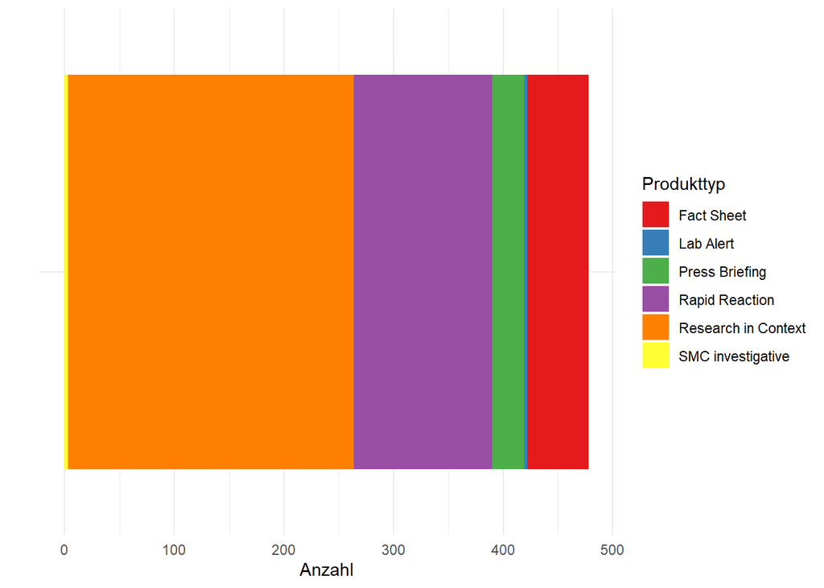

```r
tmp <- tibble(Produkttyp = c("Research in Context", "Rapid Reaction", "Fact Sheet", "Press Briefing", "SMC investigative", "Lab Alert"),
       Anzahl = c(261,126,56,29,3,3)) %>%
   ggplot(aes(x = "", y = Anzahl, fill = Produkttyp)) +
   geom_bar(stat = "identity", position = "stack") +
   scale_x_discrete(name = "") +
   scale_fill_brewer(type = "qual", palette = "Set1") +
   coord_flip()
tmp
```

```r
ggsave(filename = "p00_Produkttyp.png", plot = tmp, device = "png", width = 250, height = 100, scale = scale_glob, units = "mm")
```

### F1 Wie lässt sich die Wissenschaftsberichterstattung deutschsprachiger Medien

unter Beteiligung des SMC charakterisieren?

#### F1.1 Welche Themengebiete dominieren?

##### Aussendungen

```r
storyData %>% group_by(ressort) %>% summarise(n = n()) %>% kable()
```

| ressort | n |
| --- | --- |
| Energie | 16 |
| Klima | 35 |
| Lebenswiss. | 27 |
| Medizin | 147 |
| Technik | 70 |
| Umwelt | 71 |

```r
tmp <- storyData %>% group_by(ressort, Jahr) %>% summarise(n = n())
tmp %>% pivot_wider(names_from = "Jahr", values_from = n) %>% select(ressort, order(colnames(.))) %>% kable()
```

| ressort | 2016-01-01 | 2017-01-01 | 2018-01-01 | 2019-01-01 |
| --- | --- | --- | --- | --- |
| Energie | 3 | 4 | 2 | 7 |
| Klima | 2 | 7 | 6 | 20 |
| Lebenswiss. | 1 | 4 | 9 | 13 |
| Medizin | 16 | 36 | 35 | 60 |
| Technik | 6 | 14 | 27 | 23 |
| Umwelt | 12 | 12 | 24 | 23 |

```r
csv <- tmp %>% pivot_wider(names_from = "Jahr", values_from = n) %>% select(ressort, order(colnames(.)))
# write.csv(csv, fileEncoding = "UTF-8", file = "tab_ressort.csv")
csv[,-1] <- t(t(csv[,-1]) / colSums(csv[,-1], na.rm = TRUE))
# write.csv(csv, fileEncoding = "UTF-8", file = "tab_ressort_rel.csv")
```

```r
tmp %>% pivot_wider(names_from = Jahr, values_from = n) %>% kable()
```

| ressort | 2016-01-01 | 2017-01-01 | 2018-01-01 | 2019-01-01 |
| --- | --- | --- | --- | --- |
| Energie | 3 | 4 | 2 | 7 |
| Klima | 2 | 7 | 6 | 20 |
| Lebenswiss. | 1 | 4 | 9 | 13 |
| Medizin | 16 | 36 | 35 | 60 |
| Technik | 6 | 14 | 27 | 23 |
| Umwelt | 12 | 12 | 24 | 23 |

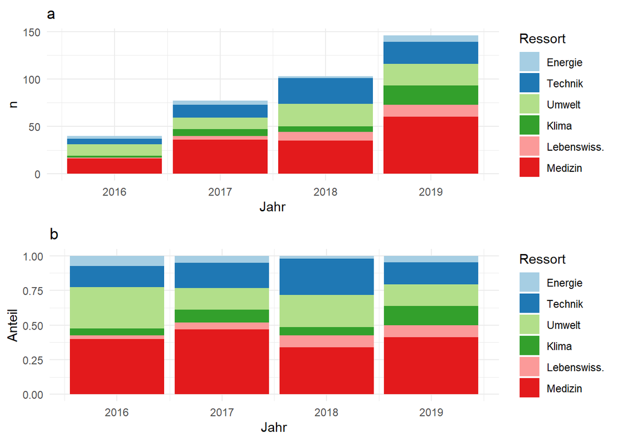

```r
tmp$ressort <- factor(tmp$ressort, levels = c("Energie", "Technik", "Umwelt", "Klima", "Lebenswiss.", "Medizin"))
# Produkte des SMC
plot1 <- tmp %>% ggplot(aes(fill = ressort, y = n, x = Jahr)) +
   geom_bar(position="stack", stat="identity") +
   labs(title = "a", fill = "Ressort") +
   scale_fill_brewer(type = "qual", palette = "Paired")
# Anteil der Ressorts
plot2 <- tmp %>% ggplot(aes(fill = ressort, y = n, x = Jahr)) +
   geom_bar(position="fill", stat="identity") +
   labs(title = "b", fill = "Ressort", y = "Anteil") +
   scale_fill_brewer(type = "qual", palette = "Paired")
grid.arrange(plot1, plot2, nrow=2)
```

##### Treffer Press Clipping

```r
tmp <- left_join(reports, storyData, by = "storyNo") %>%
   group_by(ressort.y, Jahr) %>% summarise(n = n())
csv <- tmp %>% pivot_wider(names_from = "Jahr", values_from = n)
# write.csv(csv, fileEncoding = "UTF-8", file = "tab_reports_ressort.csv")
csv[,-1] <- t(t(csv[,-1]) / colSums(csv[,-1], na.rm = TRUE))
# write.csv(csv, fileEncoding = "UTF-8", file = "tab_reports_ressort_rel.csv")
tmp$ressort.y <- factor(tmp$ressort.y, levels = c("Energie", "Technik", "Umwelt", "Klima", "Lebenswiss.", "Medizin"))
tmp %>% pivot_wider(names_from = Jahr, values_from = n) %>% kable()
```

| ressort.y | 2016-01-01 | 2017-01-01 | 2018-01-01 | 2019-01-01 |
| --- | --- | --- | --- | --- |
| Energie | 5 | 18 | 1 | 86 |
| Klima | 6 | 126 | 176 | 773 |
| Lebenswiss. | NA | 18 | 205 | 416 |
| Medizin | 167 | 806 | 1072 | 1398 |
| Technik | 5 | 68 | 732 | 345 |
| Umwelt | 39 | 400 | 276 | 595 |

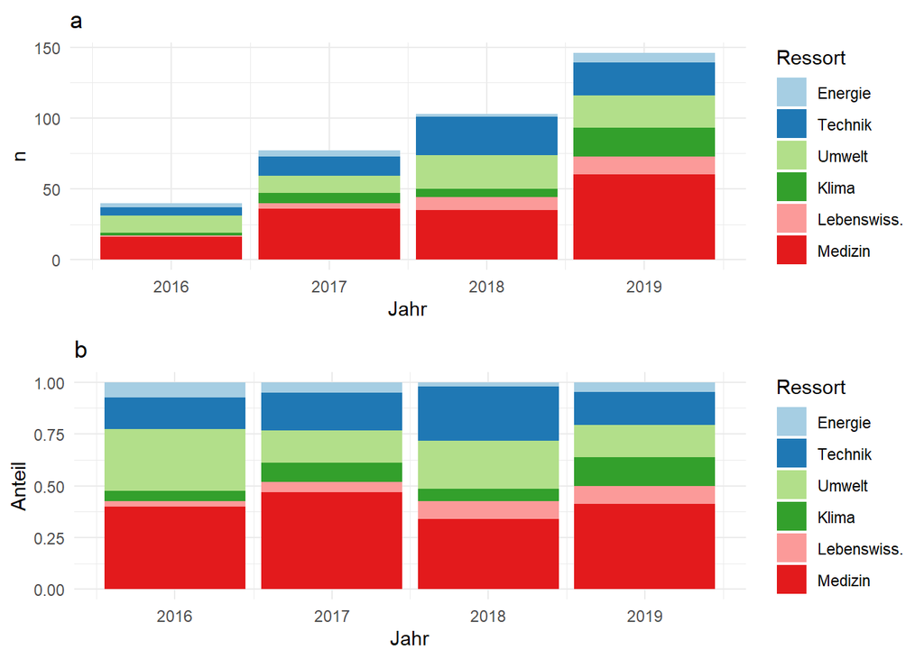

```r
# Treffer im Press Clipping
plot3 <- tmp %>% ggplot(aes(fill = ressort.y, y = n, x = Jahr)) +
   geom_bar(position="stack", stat="identity") +
   labs(title = "c", fill = "Ressort") +
   scale_fill_brewer(type = "qual", palette = "Paired")
# Anteil der Themengebiete
plot4 <- tmp %>% ggplot(aes(fill = ressort.y, y = n, x = Jahr)) +
   geom_bar(position="fill", stat="identity") +
   labs(title = "d", y = "Anteil", fill = "Ressort") +
   scale_fill_brewer(type = "qual", palette = "Paired")
grid.arrange(plot1, plot2, nrow=2)
```

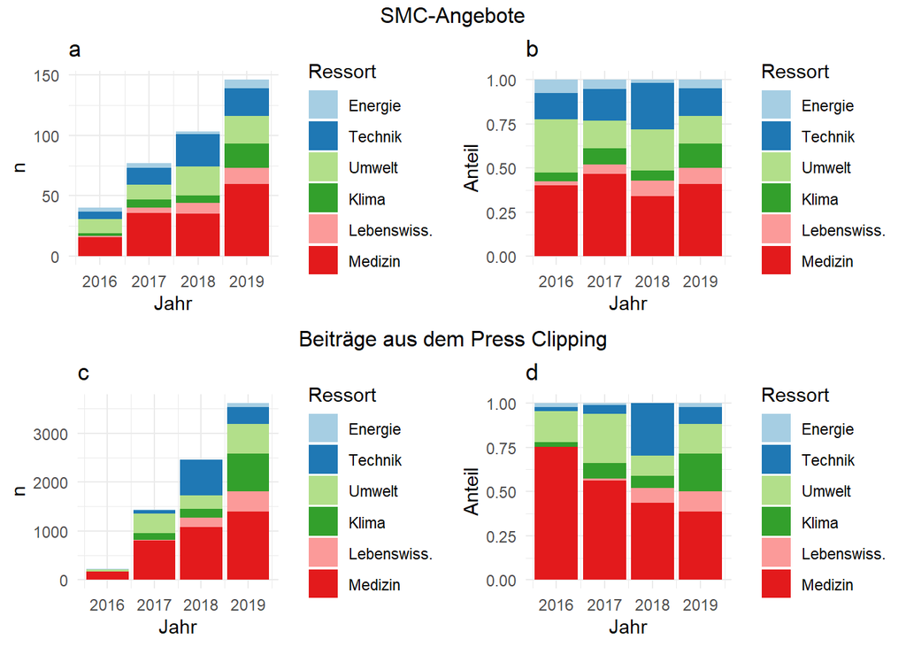

```r
tmp <- grid.arrange(arrangeGrob(plot1, plot2, ncol = 2, top = "SMC-Angebote"),
                    arrangeGrob(plot3, plot4, ncol = 2, top = "Beiträge aus dem Press Clipping"))
```

```r
ggsave(filename = "p11_Themengebiete.png", plot = tmp, device = "png", width = 150, height = 150, scale = scale_glob, units = "mm")
```

#### 1.2 Inwiefern unterscheidet sich die Nutzung von SMC-Material zwischen aktuellen

Anlässen innerhalb und außerhalb der Wissenschaft?

```r
left_join(Stamm_Faelle, storyData, by = "storyNo") %>%
   group_by(Anlasstyp, Jahr) %>% summarise(n = n()) %>% arrange(Jahr) %>% pivot_wider(names_from = "Jahr", values_from = "n") %>% kable()
```

| Anlasstyp | 2017-01-01 | 2018-01-01 | 2019-01-01 |
| --- | --- | --- | --- |
| aktuell, wissenschaftsgeneriert | 25 | 57 | 54 |
| aktuell, nicht wissenschaftsgeneriert | NA | 5 | 3 |
| NA | NA | 2 | NA |

```r
tmp <- left_join(reports, storyData, by = "storyNo") %>% group_by(storyType, Jahr) %>%
  summarise(n = n())
```

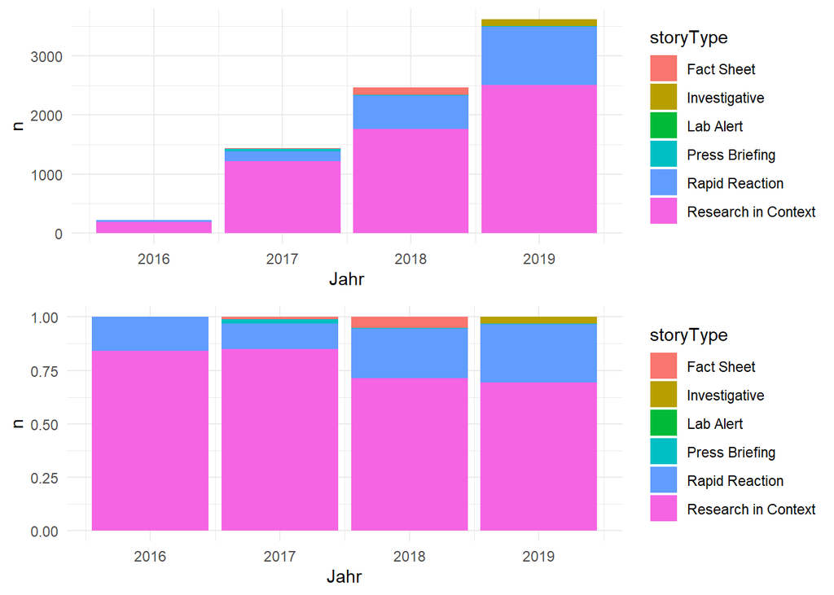

```r
plot1 <- tmp %>% ggplot(aes(fill = storyType, y = n, x = Jahr)) +
   geom_bar(position="stack", stat="identity")
plot2 <- tmp %>% ggplot(aes(fill = storyType, y = n, x = Jahr)) +
   geom_bar(position="fill", stat="identity")
grid.arrange(plot1, plot2, nrow=2)
```

Normiert auf die Aussendungen ohne Investigative:

```r
tmp <- left_join(reports, storyData, by = "storyNo") %>% group_by(storyType, Jahr) %>%
  filter(storyType %in% c("Research in Context", "Rapid Reaction")) %>% summarise(n = n())
tmp2 <- storyData %>% group_by(storyType, Jahr) %>% summarise(gesamt = n())
```

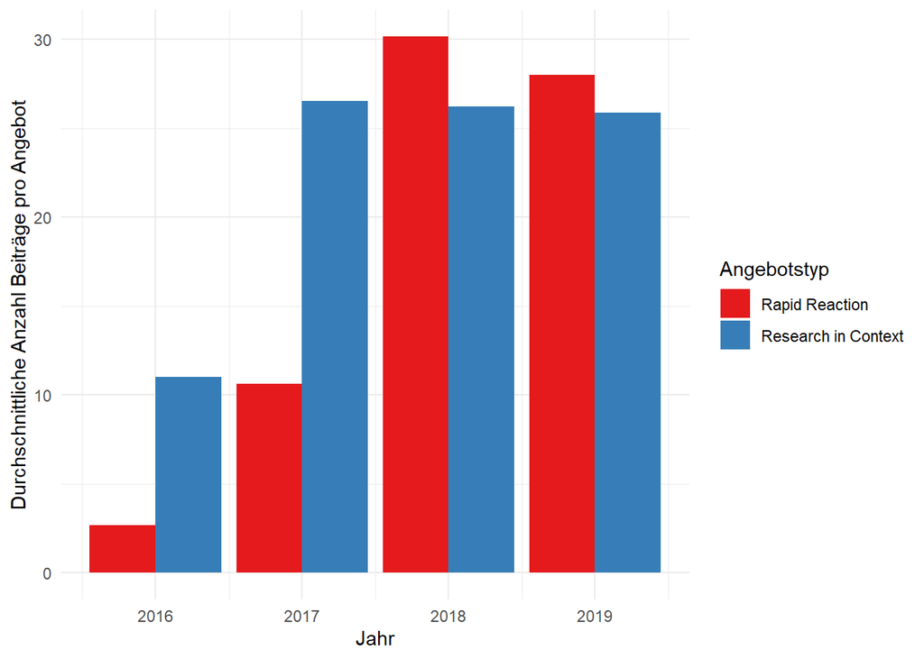

```r
tmp <- left_join(tmp, tmp2, by = c("storyType", "Jahr")) %>% mutate(ratio = n / gesamt)

plot1 <- tmp %>% ggplot(aes(fill = storyType, y = ratio, x = Jahr)) +
   scale_fill_brewer(type = "qual", palette = "Set1") +
   geom_bar(position="dodge", stat="identity") +
   scale_y_continuous(name = "Durchschnittliche Anzahl Beiträge pro Angebot") +
   labs(fill = "Angebotstyp")

plot1
```

```r
ggsave(filename = "p15_Beitraege_pro_Angebot.png", plot = plot1, device = "png", width = 150, height = 100, scale = scale_glob, units = "mm")

tmp %>% kable()
```

| storyType | Jahr | n | gesamt | ratio |
| --- | --- | --- | --- | --- |
| Rapid Reaction | 2016-01-01 | 35 | 13 | 2.692308 |
| Rapid Reaction | 2017-01-01 | 170 | 16 | 10.625000 |
| Rapid Reaction | 2018-01-01 | 573 | 19 | 30.157895 |
| Rapid Reaction | 2019-01-01 | 980 | 35 | 28.000000 |
| Research in Context | 2016-01-01 | 187 | 17 | 11.000000 |
| Research in Context | 2017-01-01 | 1220 | 46 | 26.521739 |
| Research in Context | 2018-01-01 | 1757 | 67 | 26.223881 |
| Research in Context | 2019-01-01 | 2510 | 97 | 25.876289 |

Vergleich der Themengebiete:

```r
tmp <- reports %>% select(-ressort) %>% left_join(storyData, by = "storyNo") %>%
   group_by(storyType, ressort) %>%
   filter(storyType %in% c("Research in Context", "Rapid Reaction")) %>% summarise(n = n())
tmp2 <- storyData %>% group_by(storyType, ressort) %>% summarise(gesamt = n())
```

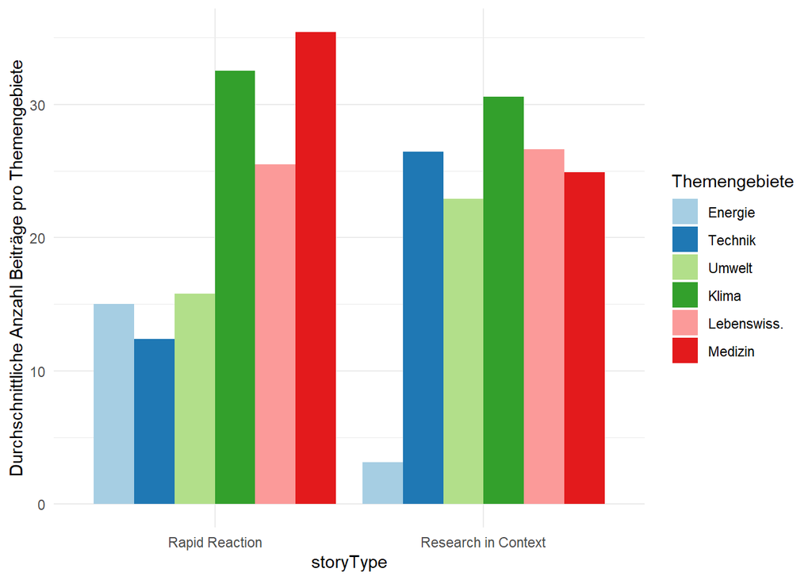

```r
tmp <- left_join(tmp, tmp2, by = c("storyType", "ressort")) %>% mutate(ratio = n / gesamt) %>%
      mutate(ressort = factor(ressort, levels = c("Energie", "Technik", "Umwelt", "Klima", "Lebenswiss.", "Medizin")))

plot1 <- tmp %>% ggplot(aes(fill = ressort, y = ratio, x = storyType)) +
   scale_fill_brewer(type = "qual", palette = "Paired") +
   geom_bar(position="dodge", stat="identity") +
   scale_y_continuous(name = "Durchschnittliche Anzahl Beiträge pro Themengebiete") +
   labs(fill = "Themengebiete")

plot1
```

```r
ggsave(filename = "p15_Beitraege_pro_Angebot_Themengebiete.png", plot = plot1, device = "png", width = 150, height = 100, scale = scale_glob, units = "mm")

tmp %>% kable()
```

| storyType | ressort | n | gesamt | ratio |
| --- | --- | --- | --- | --- |
| Rapid Reaction | Energie | 90 | 6 | 15.000000 |
| Rapid Reaction | Klima | 195 | 6 | 32.500000 |
| Rapid Reaction | Lebenswiss. | 51 | 2 | 25.500000 |
| Rapid Reaction | Medizin | 779 | 22 | 35.409091 |
| Rapid Reaction | Technik | 359 | 29 | 12.379310 |
| Rapid Reaction | Umwelt | 284 | 18 | 15.777778 |
| Research in Context | Energie | 19 | 6 | 3.166667 |
| Research in Context | Klima | 886 | 29 | 30.551724 |
| Research in Context | Lebenswiss. | 586 | 22 | 26.636364 |
| Research in Context | Medizin | 2514 | 101 | 24.891089 |
| Research in Context | Technik | 661 | 25 | 26.440000 |
| Research in Context | Umwelt | 1008 | 44 | 22.909091 |

#### F1.3 Wie verteilt sich die SMC-Nutzung auf die Mediengattungen?

```r
tmp <- left_join(reports, storyData, by = "storyNo") %>% group_by(sourceType, Jahr) %>% summarise(n = n())
tmp %>% pivot_wider(names_from = Jahr, values_from = n) %>% kable()
```

| sourceType | 2019-01-01 | 2016-01-01 | 2017-01-01 | 2018-01-01 |
| --- | --- | --- | --- | --- |
| Anderes | 2 | NA | NA | NA |
| Nachrichtenagentur | 44 | 1 | 21 | 21 |
| Online | 2599 | 150 | 1198 | 2178 |
| Print | 957 | 68 | 206 | 259 |
| Radio | 10 | 2 | 11 | 3 |
| TV | 1 | 1 | NA | 1 |

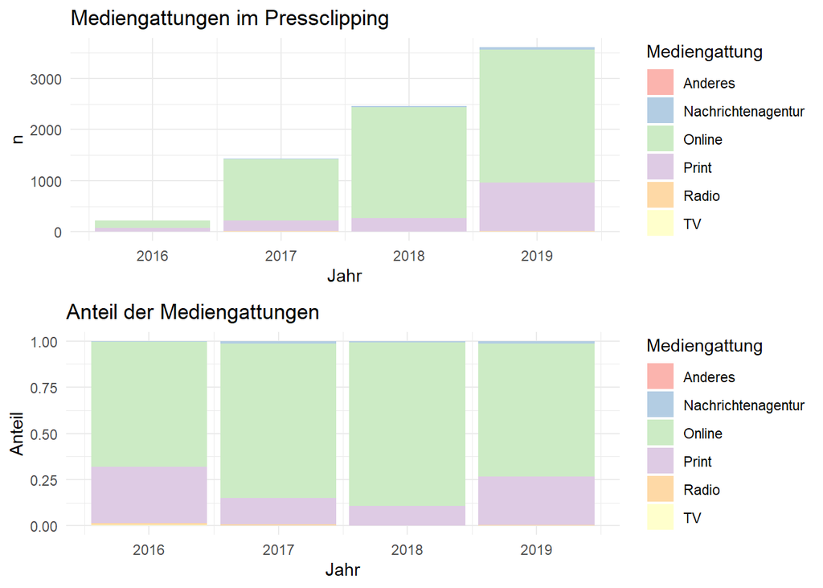

```r
plot1 <- tmp %>% ggplot(aes(fill = sourceType, y = n, x = Jahr)) +
   geom_bar(position="stack", stat="identity") +
   labs(title = "Mediengattungen im Pressclipping", fill = "Mediengattung") +
   scale_fill_brewer(type = "qual", palette = "Pastel1")
plot2 <- tmp %>% ggplot(aes(fill = sourceType, y = n, x = Jahr)) +
   geom_bar(position="fill", stat="identity") +
   labs(title = "Anteil der Mediengattungen", fill = "Mediengattung", y = "Anteil") +
   scale_fill_brewer(type = "qual", palette = "Pastel1")
grid.arrange(plot1, plot2, nrow=2)
```

#### F1.4 Welche Ressorts greifen SMC-begleitete Anlässe auf?

```r
reports %>% filter(!(ressort == "")) %>%  group_by(ressort) %>% summarise(n = n()) %>% arrange(desc(n)) %>% kable()
```

| ressort | n |
| --- | --- |
| Wissen | 62 |
| Wissenschaft | 62 |
| Gesundheit | 29 |
| Nachrichten | 29 |
| Panorama | 17 |
| News | 13 |
| Story | 10 |
| Medizin | 7 |
| Leben | 5 |
| // | 4 |
| Politik | 4 |
| Wissenschat | 4 |
| Aktuell | 3 |
| Digital | 3 |
| Magazin | 3 |
| Natur und Wissenschaft | 3 |
| Newsticker | 3 |
| / | 2 |
| aktuell | 2 |
| Aus aller Welt | 2 |
| Gesellschaft | 2 |
| Gesundheit-Medizin | 2 |
| Netzwelt | 2 |
| Überregional | 2 |
| Welt | 2 |
| Weltspiegel | 2 |
| Feuilleton | 1 |
| Arbeit | 1 |
| Ausland | 1 |
| Bauchemie | 1 |
| Beitrag | 1 |
| Blog | 1 |
| Bremen | 1 |
| Deutschland und die Welt | 1 |
| Deutschland und Welt | 1 |
| Echo Vermischtes | 1 |
| Entertainment | 1 |
| Erbe und Umwelt | 1 |
| Faktenfinder | 1 |
| Familie | 1 |
| Famulie | 1 |
| Feuilleton | 1 |
| Forschung aktuell | 1 |
| Front | 1 |
| Gesundheit und Medizin | 1 |
| Inland | 1 |
| IT/Tech | 1 |
| Kolumne | 1 |
| Kultur | 1 |
| Lebensart | 1 |
| Lifestyle | 1 |
| lokal | 1 |
| Lokales | 1 |
| Magazine | 1 |
| Nachricht | 1 |
| Nachrichten Politik | 1 |
| Pan | 1 |
| Politk | 1 |
| Presseschau | 1 |
| Science | 1 |
| Service | 1 |
| Sonstiges | 1 |
| Stories | 1 |
| story | 1 |
| Sucht | 1 |
| Technik | 1 |
| Thema | 1 |
| Thema | 1 |
| Themen | 1 |
| today | 1 |
| Umwelt | 1 |
| Web | 1 |
| Wirtschaft | 1 |
| Wiss | 1 |
| wissen | 1 |
| Wissen aktuell | 1 |
| Wissen und Gesellschaft | 1 |
| Wissen und Geselschaft | 1 |
| Wissen/Forschen | 1 |
| Zeitgeschehen | 1 |

#### F1.5 Wie verteilt sich die SMC-Nutzung auf deutsche, österreichische und schweizerische Medien?

```r
tmp <- left_join(reports, storyData, by = "storyNo") %>% mutate(Laendercode = if_else(!(Laendercode %in% c("AT", "CH", "DE"))|is.na(Laendercode), "sonstige", Laendercode)) %>%  group_by(Laendercode, Jahr) %>%
  summarise(n = n()) %>% arrange(desc(n))
tmp %>% pivot_wider(names_from = Jahr, values_from = n) %>% kable()
```

| Laendercode | 2019-01-01 | 2018-01-01 | 2017-01-01 | 2016-01-01 |
| --- | --- | --- | --- | --- |
| DE | 3271 | 2207 | 1276 | 198 |
| CH | 167 | 122 | 62 | 6 |
| AT | 141 | 112 | 66 | 7 |
| sonstige | 34 | 21 | 32 | 11 |

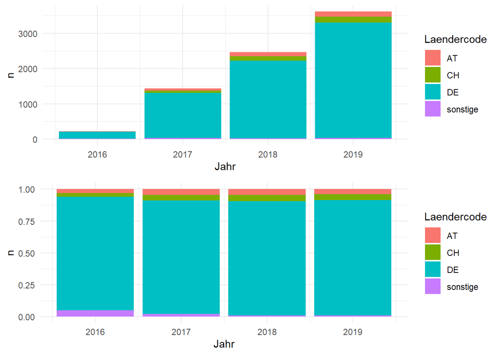

```r
plot1 <- tmp %>% ggplot(aes(fill = Laendercode, y = n, x = Jahr)) +
   geom_bar(position="stack", stat="identity")
plot2 <- tmp %>% ggplot(aes(fill = Laendercode, y = n, x = Jahr)) +
   geom_bar(position="fill", stat="identity")
grid.arrange(plot1, plot2, nrow=2)
```

##### Bezug: F2.2 Besteht ein Zusammenhang zwischen der Anzahl sowie der Chronologie der Expertenstatements und ihrer Verwendung durch Journalist*innen?

```r
tmp <- left_join(experts, storyData, by = "storyNo") %>% filter(storyType %in% c("Rapid Reaction", "Research in Context")) %>% group_by(storyNo) %>% summarise(experts = n())
tmp2 <- left_join(reports, storyData, by = "storyNo") %>% filter(storyType %in% c("Rapid Reaction", "Research in Context")) %>% group_by(storyNo) %>% summarise(reports = n())
tmp <- left_join(tmp, tmp2, by = "storyNo") %>% mutate(reports = if_else(is.na(reports), 0L, reports))
cor(tmp$experts, tmp$reports)
```

```
## [1] 0.1743608
```

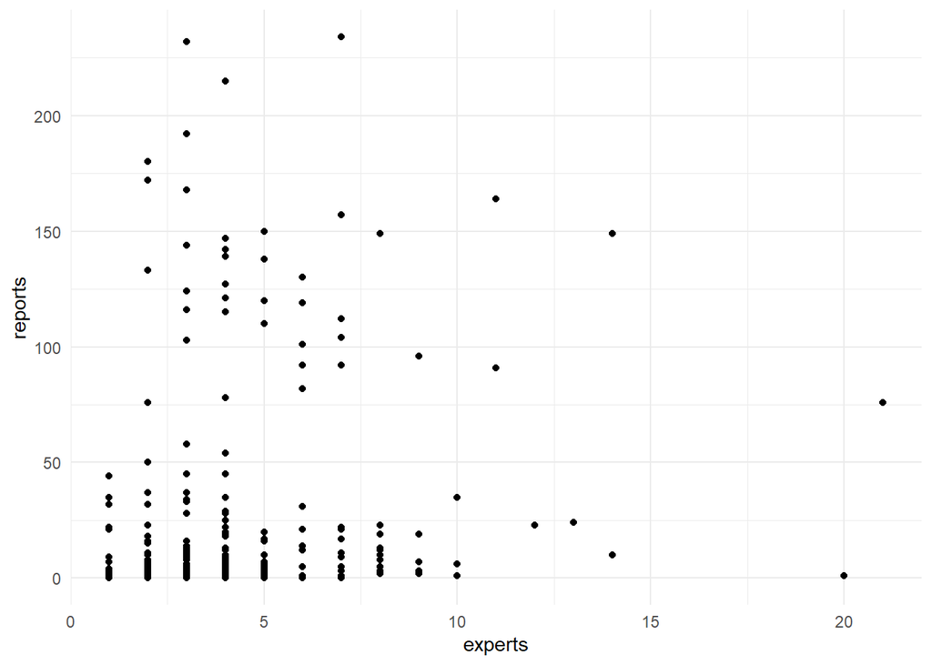

```r
tmp %>% ggplot(aes(y = reports, x = experts)) +
   geom_point()
```

#### F1.7 Welcher Dynamik folgt die Wissenschaftsberichterstattung? Welche Unterschiede

gibt es zwischen den verschiedenen Anlasstypen? Welche Medien lassen sich als Leitmedien, welche als Follower-Medien bezeichnen? Stimmen sie mit den klassischen Leitmedien überein?

```r
alteLabel <- c("",
               "direkt via Press Briefing",
               "direkt via SMC Aussendung (akkreditierte Journalisten)",
               "direkt via SMC Int. Aussendung",
               "indirekt via Nachrichtenagentur",
               "indirekt via SMC Homepage",
               "indirekt via zitierendem Medium",
               "Themen-/ Expertenfindung")

neueLabel <- c("fehlend" ,
               "Sonstiges",
               "direkt via SMC-Aussendung",
               "Sonstiges",
               "indirekt via Nachrichtenagentur",
               "Sonstiges",
               "indirekt via zitierendem Medium",
               "Themen- und Expertenfindung")

tmp <- left_join(reports, storyData, by = "storyNo") %>% group_by(modeOfUse, Jahr) %>%
   mutate(modeOfUse = neueLabel[match(modeOfUse, alteLabel)]) %>%
   summarise(n = n()) %>%
   mutate(modeOfUse = factor(modeOfUse, levels = c("direkt via SMC-Aussendung",
                                                   "indirekt via Nachrichtenagentur", "indirekt via zitierendem Medium",
                                                   "Themen- und Expertenfindung", "Sonstiges", "fehlend")))
```

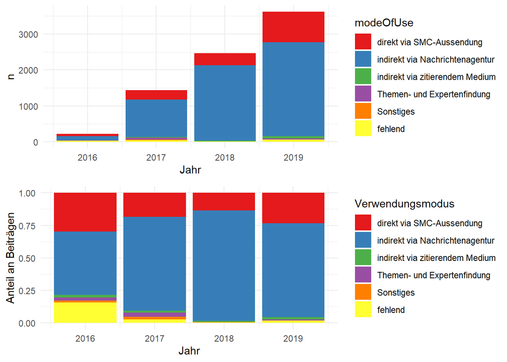

```r
plot1 <- tmp %>% ggplot(aes(fill = modeOfUse, y = n, x = Jahr)) +
   geom_bar(position="stack", stat="identity") +
   scale_fill_brewer(type = "qual", palette = "Set1")
plot2 <- tmp %>% ggplot(aes(fill = modeOfUse, y = n, x = Jahr)) +
   geom_bar(position="fill", stat="identity") +
   scale_fill_brewer(type = "qual", palette = "Set1") +
   scale_y_continuous(name = "Anteil an Beiträgen") +
   labs(fill = "Verwendungsmodus")
grid.arrange(plot1, plot2, nrow=2)
```

```r
ggsave(filename = "p17_modeOfUse.png", plot = plot2, device = "png", width = 150, height = 100, scale = scale_glob, units = "mm")

tmp %>% kable()
```

| modeOfUse | Jahr | n |
| --- | --- | --- |
| direkt via SMC-Aussendung | 2016-01-01 | 66 |
| direkt via SMC-Aussendung | 2017-01-01 | 265 |
| direkt via SMC-Aussendung | 2018-01-01 | 332 |
| direkt via SMC-Aussendung | 2019-01-01 | 846 |
| fehlend | 2016-01-01 | 35 |
| fehlend | 2017-01-01 | 40 |
| fehlend | 2018-01-01 | 8 |
| fehlend | 2019-01-01 | 64 |
| indirekt via Nachrichtenagentur | 2016-01-01 | 108 |
| indirekt via Nachrichtenagentur | 2017-01-01 | 1038 |
| indirekt via Nachrichtenagentur | 2018-01-01 | 2092 |
| indirekt via Nachrichtenagentur | 2019-01-01 | 2609 |
| indirekt via zitierendem Medium | 2016-01-01 | 5 |
| indirekt via zitierendem Medium | 2017-01-01 | 19 |
| indirekt via zitierendem Medium | 2018-01-01 | 21 |
| indirekt via zitierendem Medium | 2019-01-01 | 58 |
| Sonstiges | 2016-01-01 | 3 |
| Sonstiges | 2017-01-01 | 29 |
| Sonstiges | 2018-01-01 | 8 |
| Sonstiges | 2019-01-01 | 2 |
| Themen- und Expertenfindung | 2016-01-01 | 5 |
| Themen- und Expertenfindung | 2017-01-01 | 45 |
| Themen- und Expertenfindung | 2018-01-01 | 1 |
| Themen- und Expertenfindung | 2019-01-01 | 34 |

##### Leitmedien und Follower-Medien der Wissenschaftsberichterstattung & Übereinstimmung klassische Leitmedien

Einbezogen sind nur Medien mit mehr als fünf nicht-Agentur-Reports. Betrachtet werden nur die Reports, die nicht über eine Nachrichtenagentur gingen.

```r
RZ <- reports %>% #filter(!(modeOfUse %in% c("indirekt via Nachrichtenagentur"))) %>%
   group_by(storyNo) %>% mutate(lag = published - min(published, na.rm = TRUE))
tmp <- RZ %>%
   filter(!(modeOfUse %in% c("indirekt via Nachrichtenagentur"))) %>%
   group_by(mediaOutlet) %>%
   filter(n() > 5) %>%
  summarise(n = n(),
            t0 = sum(lag == 0, na.rm = TRUE),
            t1 = sum(lag == 1, na.rm = TRUE),
            t2 = sum(lag == 2, na.rm = TRUE),
            t3 = sum(lag == 3, na.rm = TRUE),
            t4 = sum(lag == 4, na.rm = TRUE),
            t5 = sum(lag == 5, na.rm = TRUE),
            t6 = sum(lag == 6, na.rm = TRUE),
            t7 = sum(lag == 7, na.rm = TRUE),
            tg7 = sum(lag > 7, na.rm = TRUE),
            median = median(lag, na.rm = TRUE),
            mean = round(mean(lag, na.rm = TRUE), 2),
            median7 = median(lag[lag<=7], na.rm = TRUE),
            mean7 = round(mean(lag[lag<=7], na.rm = TRUE), 2)
            ) %>%
#   arrange(median, mean) %>%
   arrange(median, mean)
tmp %>% kable()
```

| mediaOutlet | n | t0 | t1 | t2 | t3 | t4 | t5 | t6 | t7 | tg7 | median | mean | median7 | mean7 |
| --- | --- | --- | --- | --- | --- | --- | --- | --- | --- | --- | --- | --- | --- | --- |
| Elbe-Jeetzel-Zeitung Online | 7 | 7 | 0 | 0 | 0 | 0 | 0 | 0 | 0 | 0 | 0.0 days | 0.00 days | 0.0 days | 0.00 days |
| Landeszeitung für die Lüneburger Heide Online | 6 | 6 | 0 | 0 | 0 | 0 | 0 | 0 | 0 | 0 | 0.0 days | 0.00 days | 0.0 days | 0.00 days |
| Schweizer Depeschenagentur (SDA) | 10 | 10 | 0 | 0 | 0 | 0 | 0 | 0 | 0 | 0 | 0.0 days | 0.00 days | 0.0 days | 0.00 days |
| Katholische Nachrichtenagentur (KNA) | 6 | 5 | 1 | 0 | 0 | 0 | 0 | 0 | 0 | 0 | 0.0 days | 0.17 days | 0.0 days | 0.17 days |
| Deutsche Presse-Agentur (dpa) | 19 | 15 | 4 | 0 | 0 | 0 | 0 | 0 | 0 | 0 | 0.0 days | 0.21 days | 0.0 days | 0.21 days |
| PV Magazine Online | 7 | 6 | 0 | 1 | 0 | 0 | 0 | 0 | 0 | 0 | 0.0 days | 0.29 days | 0.0 days | 0.29 days |
| ORF Online | 22 | 15 | 5 | 0 | 1 | 1 | 0 | 0 | 0 | 0 | 0.0 days | 0.55 days | 0.0 days | 0.55 days |
| Der Standard Online DE | 24 | 15 | 4 | 2 | 1 | 1 | 0 | 0 | 0 | 1 | 0.0 days | 1.83 days | 0.0 days | 0.65 days |
| Ostsee-Zeitung Online | 6 | 5 | 0 | 0 | 0 | 0 | 0 | 0 | 0 | 1 | 0.0 days | 2.67 days | 0.0 days | 0.00 days |
| Heise Online | 13 | 8 | 3 | 0 | 0 | 0 | 1 | 0 | 0 | 1 | 0.0 days | 4.54 days | 0.0 days | 0.67 days |
| Süddeutsche Zeitung Online | 73 | 46 | 19 | 0 | 3 | 1 | 1 | 0 | 0 | 2 | 0.0 days | 10.64 days | 0.0 days | 0.53 days |
| Berliner Zeitung Online | 7 | 4 | 1 | 0 | 0 | 0 | 0 | 0 | 0 | 2 | 0.0 days | 12.29 days | 0.0 days | 0.20 days |
| Neue Zürcher Zeitung Online CH | 30 | 22 | 5 | 1 | 0 | 0 | 0 | 1 | 0 | 1 | 0.0 days | 12.57 days | 0.0 days | 0.45 days |
| Deutsche Welle Online | 18 | 14 | 1 | 0 | 1 | 0 | 0 | 0 | 0 | 2 | 0.0 days | 21.28 days | 0.0 days | 0.25 days |
| Der Tagesspiegel Online | 40 | 28 | 5 | 2 | 0 | 1 | 0 | 0 | 0 | 4 | 0.0 days | 21.45 days | 0.0 days | 0.36 days |
| Zeit Online | 43 | 31 | 4 | 1 | 1 | 0 | 0 | 0 | 1 | 5 | 0.0 days | 28.42 days | 0.0 days | 0.42 days |
| wissenschaft.de | 13 | 8 | 3 | 0 | 0 | 0 | 0 | 0 | 0 | 1 | 0.0 days | 30.58 days | 0.0 days | 0.27 days |
| Leipziger Volkszeitung Online | 7 | 5 | 0 | 0 | 0 | 0 | 0 | 0 | 0 | 2 | 0.0 days | 34.43 days | 0.0 days | 0.00 days |
| Spektrum Online | 25 | 15 | 2 | 0 | 1 | 0 | 1 | 0 | 0 | 6 | 0.0 days | 52.32 days | 0.0 days | 0.53 days |
| Deutschlandfunk Radio | 7 | 3 | 3 | 0 | 0 | 0 | 0 | 0 | 0 | 0 | 0.5 days | 0.50 days | 0.5 days | 0.50 days |
| Deutsche Apotheker Zeitung Online | 6 | 3 | 1 | 1 | 0 | 0 | 0 | 0 | 0 | 1 | 0.5 days | 3.17 days | 0.0 days | 0.60 days |
| RBB Online | 10 | 5 | 1 | 1 | 0 | 0 | 0 | 2 | 0 | 1 | 0.5 days | 3.70 days | 0.0 days | 1.67 days |
| MDR Online | 17 | 7 | 7 | 0 | 1 | 0 | 0 | 0 | 0 | 0 | 1.0 days | 0.67 days | 1.0 days | 0.67 days |
| BR Online | 8 | 2 | 5 | 1 | 0 | 0 | 0 | 0 | 0 | 0 | 1.0 days | 0.88 days | 1.0 days | 0.88 days |
| Stern Online | 12 | 4 | 5 | 2 | 1 | 0 | 0 | 0 | 0 | 0 | 1.0 days | 1.00 days | 1.0 days | 1.00 days |
| Der Standard Online AT | 49 | 23 | 13 | 6 | 2 | 3 | 2 | 0 | 0 | 0 | 1.0 days | 1.08 days | 1.0 days | 1.08 days |
| Potsdamer Neueste Nachrichten Print | 12 | 0 | 9 | 3 | 0 | 0 | 0 | 0 | 0 | 0 | 1.0 days | 1.25 days | 1.0 days | 1.25 days |
| Die Welt Kompakt Print | 6 | 0 | 5 | 0 | 1 | 0 | 0 | 0 | 0 | 0 | 1.0 days | 1.33 days | 1.0 days | 1.33 days |
| WDR Online | 21 | 8 | 6 | 2 | 3 | 1 | 0 | 0 | 0 | 1 | 1.0 days | 1.62 days | 1.0 days | 1.15 days |
| Tages-Anzeiger Online | 9 | 2 | 4 | 0 | 0 | 0 | 0 | 1 | 0 | 1 | 1.0 days | 2.50 days | 1.0 days | 1.43 days |
| Der Bund Online CH | 7 | 1 | 4 | 0 | 0 | 0 | 1 | 0 | 0 | 1 | 1.0 days | 2.71 days | 1.0 days | 1.50 days |
| Basler Zeitung Online | 7 | 1 | 3 | 0 | 0 | 0 | 1 | 0 | 0 | 1 | 1.0 days | 3.00 days | 1.0 days | 1.60 days |
| Deutschlandfunk Online | 24 | 11 | 10 | 0 | 0 | 1 | 0 | 0 | 0 | 2 | 1.0 days | 5.92 days | 0.5 days | 0.64 days |
| Die Tageszeitung taz Online | 7 | 3 | 3 | 0 | 0 | 0 | 0 | 0 | 0 | 1 | 1.0 days | 6.86 days | 0.5 days | 0.50 days |
| Deutsches Ärzteblatt Online | 77 | 35 | 22 | 4 | 1 | 4 | 1 | 0 | 1 | 7 | 1.0 days | 11.91 days | 0.0 days | 0.90 days |
| Der Tagesspiegel Print | 41 | 5 | 25 | 6 | 0 | 0 | 0 | 0 | 0 | 5 | 1.0 days | 13.29 days | 1.0 days | 1.03 days |
| Der Standard Print | 30 | 6 | 18 | 2 | 1 | 1 | 0 | 0 | 1 | 1 | 1.0 days | 13.40 days | 1.0 days | 1.24 days |
| Süddeutsche Zeitung Print | 81 | 5 | 51 | 10 | 0 | 4 | 3 | 1 | 2 | 4 | 1.0 days | 15.95 days | 1.0 days | 1.61 days |
| Die Welt Online | 65 | 29 | 18 | 6 | 1 | 0 | 0 | 2 | 1 | 8 | 1.0 days | 17.74 days | 0.0 days | 0.91 days |
| Berliner Zeitung Print | 23 | 3 | 12 | 3 | 0 | 0 | 1 | 0 | 0 | 3 | 1.0 days | 21.09 days | 1.0 days | 1.21 days |
| Der Spiegel Online | 30 | 14 | 11 | 0 | 2 | 1 | 0 | 0 | 0 | 2 | 1.0 days | 25.07 days | 0.5 days | 0.75 days |
| scinexx.de | 42 | 15 | 18 | 3 | 0 | 1 | 1 | 0 | 0 | 3 | 1.0 days | 27.51 days | 1.0 days | 0.87 days |
| ARD Online | 8 | 3 | 4 | 0 | 0 | 0 | 0 | 0 | 0 | 1 | 1.0 days | 27.62 days | 1.0 days | 0.57 days |
| Die Welt Print | 45 | 9 | 16 | 7 | 2 | 1 | 0 | 0 | 2 | 8 | 1.0 days | 27.71 days | 1.0 days | 1.46 days |
| SWR Online | 13 | 6 | 4 | 0 | 2 | 0 | 0 | 0 | 0 | 1 | 1.0 days | 28.85 days | 0.5 days | 0.83 days |
| Ärzte Zeitung Online | 15 | 4 | 5 | 0 | 1 | 1 | 0 | 1 | 0 | 2 | 1.0 days | 28.93 days | 1.0 days | 1.50 days |
| Frankfurter Allgemeine Zeitung Online | 40 | 19 | 7 | 1 | 2 | 0 | 1 | 2 | 1 | 7 | 1.0 days | 33.83 days | 0.0 days | 1.18 days |
| Tages-Anzeiger Print | 10 | 0 | 7 | 0 | 0 | 0 | 0 | 0 | 0 | 3 | 1.0 days | 39.20 days | 1.0 days | 1.00 days |
| Focus Online | 21 | 4 | 6 | 1 | 1 | 1 | 2 | 1 | 0 | 3 | 1.0 days | 54.79 days | 1.0 days | 1.94 days |
| N-tv Online | 6 | 2 | 3 | 0 | 0 | 0 | 0 | 0 | 0 | 1 | 1.0 days | 61.33 days | 1.0 days | 0.60 days |
| Stuttgarter Nachrichten Online | 7 | 1 | 3 | 0 | 0 | 0 | 1 | 0 | 0 | 2 | 1.0 days | 64.57 days | 1.0 days | 1.60 days |
| Stuttgarter Nachrichten Print | 10 | 2 | 3 | 2 | 1 | 0 | 0 | 0 | 0 | 2 | 1.5 days | 74.60 days | 1.0 days | 1.25 days |
| Neue Zürcher Zeitung Print | 24 | 3 | 7 | 6 | 1 | 3 | 0 | 1 | 2 | 1 | 2.0 days | 17.58 days | 2.0 days | 2.35 days |
| Frankfurter Allgemeine Zeitung Print | 38 | 6 | 12 | 10 | 0 | 0 | 3 | 1 | 1 | 5 | 2.0 days | 36.05 days | 1.0 days | 1.82 days |
| Stuttgarter Zeitung Print | 18 | 3 | 3 | 5 | 1 | 0 | 1 | 1 | 0 | 4 | 2.0 days | 43.72 days | 2.0 days | 1.93 days |
| Frankfurter Rundschau Online | 14 | 1 | 3 | 1 | 2 | 1 | 2 | 1 | 1 | 2 | 3.5 days | 4.21 days | 3.0 days | 3.17 days |
| Stuttgarter Zeitung Online | 6 | 1 | 1 | 1 | 0 | 0 | 1 | 0 | 0 | 2 | 3.5 days | 64.83 days | 1.5 days | 2.00 days |
| klimareporter.de | 7 | 2 | 1 | 0 | 0 | 0 | 2 | 0 | 1 | 1 | 5.0 days | 3.71 days | 3.0 days | 3.00 days |
| Frankfurter Rundschau Print | 17 | 2 | 3 | 1 | 1 | 1 | 4 | 0 | 2 | 3 | 5.0 days | 4.47 days | 3.5 days | 3.29 days |
| Bergische Morgenpost Print | 6 | 1 | 1 | 0 | 0 | 0 | 1 | 0 | 2 | 1 | 6.0 days | 7.00 days | 5.0 days | 4.00 days |
| Bonner General-Anzeiger Print | 22 | 2 | 3 | 0 | 3 | 1 | 2 | 0 | 2 | 9 | 6.0 days | 39.55 days | 3.0 days | 3.08 days |
| Rheinische Post Print | 6 | 1 | 1 | 0 | 0 | 0 | 0 | 0 | 3 | 1 | 7.0 days | 7.33 days | 7.0 days | 4.40 days |
| DocCheck Online | 11 | 2 | 0 | 0 | 1 | 1 | 0 | 0 | 0 | 7 | 12.0 days | 26.82 days | 1.5 days | 1.75 days |

```r
write_csv(tmp, path = "t17aLag.csv")
```

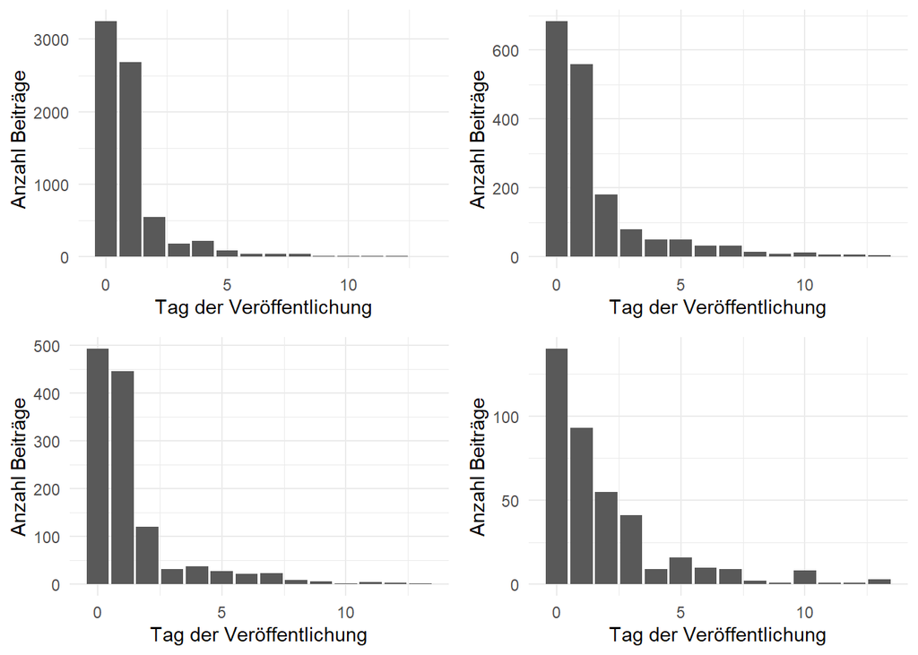

```r
plot1 <- RZ %>% group_by(lag) %>% summarise(n = n()) %>% filter(lag < 14) %>%
   ggplot(aes(y = n, x = lag)) +
   geom_bar(stat="identity") +
   xlab("Tag der Veröffentlichung") +
   ylab("Anzahl Beiträge")
plot2 <- RZ %>% filter(!(modeOfUse %in% c("indirekt via Nachrichtenagentur"))) %>%
   group_by(lag) %>% summarise(n = n()) %>% filter(lag < 14) %>%
   ggplot(aes(y = n, x = lag)) +
   geom_bar(stat="identity") +
   xlab("Tag der Veröffentlichung") +
   ylab("Anzahl Beiträge")
plot3 <- RZ %>%
   left_join(storyData, by = "storyNo") %>%
   filter(!(modeOfUse %in% c("indirekt via Nachrichtenagentur")), storyType == "Research in Context") %>%
   group_by(lag) %>% summarise(n = n()) %>% filter(lag < 14) %>%
   ggplot(aes(y = n, x = lag)) +
   geom_bar(stat="identity") +
   xlab("Tag der Veröffentlichung") +
   ylab("Anzahl Beiträge")
plot4 <- RZ %>%
   left_join(storyData, by = "storyNo") %>%
   filter(!(modeOfUse %in% c("indirekt via Nachrichtenagentur")), storyType == "Rapid Reaction") %>%
   group_by(lag) %>% summarise(n = n()) %>% filter(lag < 14) %>%
   ggplot(aes(y = n, x = lag)) +
   geom_bar(stat="identity") +
   xlab("Tag der Veröffentlichung") +
   ylab("Anzahl Beiträge")

grid.arrange(plot1, plot2, plot3, plot4, nrow=2)
```

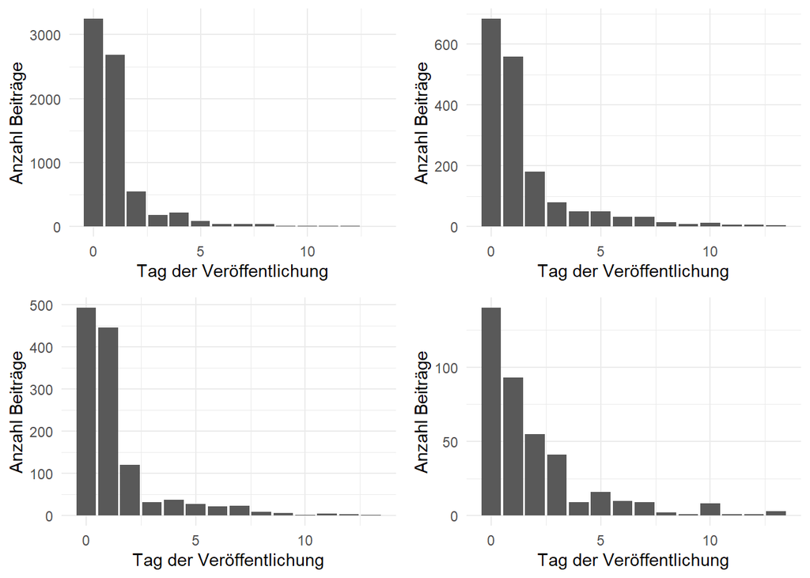

```r
ggsave(filename = "p17a_lags.png", plot = grid.arrange(plot1, plot2, plot3, plot4, nrow=2), device = "png", width = 150, height = 150, scale = scale_glob, units = "mm")
```

##### Mediale Selbstreferenz in der Wissenschaftsberichterstattung. Welche Medien referenzieren welche anderen?

Häufigkeiten: indirekt via zitierendem Medium

```r
reports %>% filter(modeOfUse == "indirekt via zitierendem Medium") %>% group_by(mediaOutlet) %>% summarise(n = n()) %>% arrange(desc(n)) %>% kable()
```

| mediaOutlet | n |
| --- | --- |
| Focus Online | 6 |
| Basler Zeitung Online | 3 |
| Der Bund Online CH | 3 |
| Berner Zeitung Online | 2 |
| DocCheck Online | 2 |
| heilpraxisnet.de | 2 |
| scinexx.de | 2 |
| Stern Online | 2 |
| Tages-Anzeiger Online | 2 |
| Tiroler Tageszeitung Online | 2 |
| agrarheute.com | 1 |
| Alb-Bote Print | 1 |
| Berner Oberländer Online | 1 |
| biermann-medizin.de | 1 |
| Bild der Frau Online | 1 |
| boerse-express.com | 1 |
| Bunte Online | 1 |
| car-it.com | 1 |
| Computer Bild Online | 1 |
| Der Standard Online DE | 1 |
| Der Standard Print | 1 |
| Die Welt Online | 1 |
| eco-world.de | 1 |
| Finanzen Online AT | 1 |
| finanznachrichten.de | 1 |
| gamestar.de | 1 |
| Geislinger Zeitung Print | 1 |
| Gmünder Tagespost Online | 1 |
| gratis-mmorpg.com | 1 |
| Haller Tagblatt Print | 1 |

[output cut: 57 more lines]

```r
reports %>% filter(modeOfUse == "indirekt via zitierendem Medium") %>% group_by(mediaOutlet) %>% filter(n()>1) %>%
  select(-storyNo) %>% kable()
```

| Treffer | title | found | published | uri | mediaOutlet | ressort | modeOfUse | sourceType | mediaUnit | Laendercode |
| --- | --- | --- | --- | --- | --- | --- | --- | --- | --- | --- |
| 3 | Ausgewertet: Medizinerinnen retten wesentlich mehr Menschenleben |  | 2016-12-21 | http://bit.ly/2i0IcDd | heilpraxisnet.de |  | indirekt via zitierendem Medium | Online | NA | DE |
| 8 | Selbst die Tiefsee ist mit Schadstoffen verseucht |  | 2017-02-14 | http://bazonline.ch/wissen/natur/selbst-die-tiefsee-ist-mit-schadstoffen-verseucht/story/23196459 | Basler Zeitung Online |  | indirekt via zitierendem Medium | Online | Basler Zeitung | CH |
| 9 | Selbst die Tiefsee ist mit Schadstoffen verseucht |  | 2017-02-14 | http://www.tagesanzeiger.ch/wissen/natur/Selbst-die-Tiefsee-ist-mit-Schadstoffen-verseucht/story/23196459 | Tages-Anzeiger Online |  | indirekt via zitierendem Medium | Online | Tages-Anzeiger | CH |
| 14 | Selbst die Tiefsee ist mit Schadstoffen verseucht |  | 2017-02-14 | http://www.derbund.ch/wissen/natur/selbst-die-tiefsee-ist-mit-schadstoffen-verseucht/story/23196459 | Der Bund Online CH |  | indirekt via zitierendem Medium | Online | Der Bund | CH |
| 11 | Ständig Blasenentzündung - das könnte der Grund sein |  | 2017-04-01 | http://www.stern.de/gesundheit/staendig-blasenentzuendung--das-koennte-der-grund-sein-7394070.html | Stern Online |  | indirekt via zitierendem Medium | Online | Stern | DE |
| 15 | Forscher können endlich erklären, was Blasenentzündungen mit Sex zu tun haben |  | 2017-04-04 | http://www.focus.de/gesundheit/ratgeber/frauenmedizin/ursache-entdeckt-darum-kommen-so-viele-blasenentzuendungen-immer-wieder_id_6884451.html | Focus Online |  | indirekt via zitierendem Medium | Online | Focus | DE |
| 13 | Niederländische Forscher finden 40 Intelligenz-Gene |  | 2017-05-23 | http://www.heilpraxisnet.de/naturheilpraxis/niederlaendische-forscher-finden-40-intelligenz-gene-20170523278338 | heilpraxisnet.de |  | indirekt via zitierendem Medium | Online | NA | DE |
| 8 | Parkinson: Stammzellen lindern Symptome; Die Zahl an Parkinson-Patienten wird sich laut Experten bis 2030 verdoppeln. Neurochirurgen transplantierten nun humane Stammzellen in Primaten und konnten so … |  | 2017-09-14 | http://news.doccheck.com/de/185795/parkinson-stammzellen-lindern-symptome/ | DocCheck Online |  | indirekt via zitierendem Medium | Online | DocCheck | DE |
| 1 | Zystitis: In 30 Minuten zur perfekten Therapie |  | 2017-10-10 | http://news.doccheck.com/de/188910/zystitis-in-30-minuten-zur-perfekten-therapie/ | DocCheck Online |  | indirekt via zitierendem Medium | Online | DocCheck | DE |
| 12 | Gentherapie hilft “Schmetterlingskind” |  | 2017-11-09 | http://www.scinexx.de/wissen-aktuell-22078-2017-11-09.html | scinexx.de |  | indirekt via zitierendem Medium | Online | NA | DE |
| 7 | Neue Studien zeigen Risiken auf: Ist Paracetamol in der Schwangerschaft okay? |  | 2019-10-02 | https://www.focus.de/familie/eltern/kindergesundheit/umstrittene-untersuchungen-paracetamol-in-der-schwangerschaft_id_11201369.html | Focus Online | Famulie | indirekt via zitierendem Medium | Online | Focus | DE |
| 123 | Weltklimarat: Van der Bellen warnt vor „dramatischen Folgen“ |  | 2018-10-08 | https://www.tt.com/politik/innenpolitik/14893118/weltklimarat-van-der-bellen-warnt-vor-dramatischen-folgen | Tiroler Tageszeitung Online |  | indirekt via zitierendem Medium | Online | Tiroler Tageszeitung | AT |
| 14 | Kohleausstieg: Bundesregierung sagt konstruktive Prüfung zu |  | 2019-01-28 | https://www.stern.de/politik/deutschland/nach-kompromiss-kohleausstieg--bundesregierung-sagt-konstruktive-pruefung-zu-8553388.html?utm_campaign=alle&utm_medium=rss-feed&utm_source=standard | Stern Online |  | indirekt via zitierendem Medium | Online | Stern | DE |
| 19 | Altmaier will bei Kohleausstieg höhere Strompreise vermeiden“ |  | 2019-01-28 | https://www.tt.com/ticker/15268330/altmaier-will-bei-kohleausstieg-hoehere-strompreise-vermeiden | Tiroler Tageszeitung Online |  | indirekt via zitierendem Medium | Online | Tiroler Tageszeitung | AT |
| 18 | Britische Studie: E-Zigaretten können beim Rauchstopp helfen |  | 2019-02-05 | https://www.focus.de/gesundheit/gesundleben/fitness/britische-studie-e-zigaretten-koennen-beim-rauchstopp-helfen_id_10281311.html | Focus Online |  | indirekt via zitierendem Medium | Online | Focus | DE |
| 30 | Sorge vor Krankenhauskeim Pseudomonas aeruginosa |  | 2019-05-15 | https://www.focus.de/wissen/natur/sorge-vor-krankenhauskeim-pseudomonas-aeruginosa_id_10714932.html | Focus Online |  | indirekt via zitierendem Medium | Online | Focus | DE |
| 111 | Neue Wälder als Klimaretter? |  | 2019-07-04 | https://www.scinexx.de/news/geowissen/neue-waelder-als-klimaretter/ | scinexx.de |  | indirekt via zitierendem Medium | Online | NA | DE |
| 117 | Gefahr aus der Wasserflasche: «Müssen jetzt handeln» |  | 2019-08-22 | https://www.tagesanzeiger.ch/wissen/natur/gefahr-aus-der-wasserflasche/story/30393826 | Tages-Anzeiger Online |  | indirekt via zitierendem Medium | Online | Tages-Anzeiger | CH |
| 119 | Gefahr aus der Wasserflasche: «Müssen jetzt handeln» |  | 2019-08-22 | https://www.derbund.ch/wissen/natur/gefahr-aus-der-wasserflasche-muessen-jetzt-handeln/story/30393826 | Der Bund Online CH |  | indirekt via zitierendem Medium | Online | Der Bund | CH |
| 121 | Gefahr aus der Wasserflasche: «Müssen jetzt handeln» |  | 2019-08-22 | https://www.bernerzeitung.ch/wissen/natur/gefahr-aus-der-wasserflasche-muessen-jetzt-handeln/story/30393826 | Berner Zeitung Online |  | indirekt via zitierendem Medium | Online | Berner Zeitung | CH |
| 123 | Gefahr aus der Wasserflasche: «Müssen jetzt handeln» |  | 2019-08-22 | https://www.bazonline.ch/wissen/natur/gefahr-aus-der-wasserflasche-muessen-jetzt-handeln/story/30393826 | Basler Zeitung Online |  | indirekt via zitierendem Medium | Online | Basler Zeitung | CH |
| 3 | Die genetischen Wurzeln der Liebe |  | 2019-09-03 | https://desktop.12app.ch/articles/13988634 | Berner Zeitung Online |  | indirekt via zitierendem Medium | Online | Berner Zeitung | CH |
| 4 | Die genetischen Wurzeln der Liebe |  | 2019-09-03 | https://desktop.12app.ch/articles/13988634 | Der Bund Online CH |  | indirekt via zitierendem Medium | Online | Der Bund | CH |
| 5 | Die genetischen Wurzeln der Liebe |  | 2019-09-03 | https://www.bazonline.ch/die-genetischen-wurzeln-der-liebe/story/19772646 | Basler Zeitung Online |  | indirekt via zitierendem Medium | Online | Basler Zeitung | CH |
| 4 | Wasserknappheit führt weltweit zu Ernteinbußen |  | 2019-09-26 | https://www.focus.de/wissen/natur/bedrohte-kornkammern-klimawandel-duerre-gefaehrdet-weizenernte_id_11185152.html | Focus Online |  | indirekt via zitierendem Medium | Online | Focus | DE |
| 8 | 300-mal so klimawirksam wie CO2: Lachgas-Ausstoß steigt schnell - und belastet Klima |  | 2019-11-19 | https://www.focus.de/wissen/natur/unterschaetzter-klimatreiber-lachgas-emissionen-beschleunigen-sich_id_11365696.html | Focus Online |  | indirekt via zitierendem Medium | Online | Focus | DE |

#### F1.6 Auf welchem Weg gelangt SMC-Material in die Medien? Welchen Einfluss

haben Nachrichtenagenturen auf die Wissenschaftsberichterstattung? Inwiefern findet sich mediale Selbstreferenz in der Wissenschaftsberichterstattung wieder?

```r
tmp <- left_join(reports, storyData, by = "storyNo") %>% filter(storyType %in% c("Research in Context", "Rapid Reaction")) %>%
   mutate(Nachrichtenagentur = if_else(modeOfUse == "indirekt via Nachrichtenagentur", "Agentur", "eigen")) %>% group_by(storyType, Nachrichtenagentur) %>% summarise(n = n())
tmp %>% pivot_wider(names_from = "Nachrichtenagentur", values_from = n) %>% kable()
```

| storyType | Agentur | eigen |
| --- | --- | --- |
| Rapid Reaction | 1330 | 428 |
| Research in Context | 4341 | 1333 |

```r
tmp %>% group_by(storyType) %>% mutate(n = n / sum(n))%>% pivot_wider(names_from = "Nachrichtenagentur", values_from = n) %>% kable()
```

| storyType | Agentur | eigen |
| --- | --- | --- |
| Rapid Reaction | 0.7565415 | 0.2434585 |
| Research in Context | 0.7650687 | 0.2349313 |

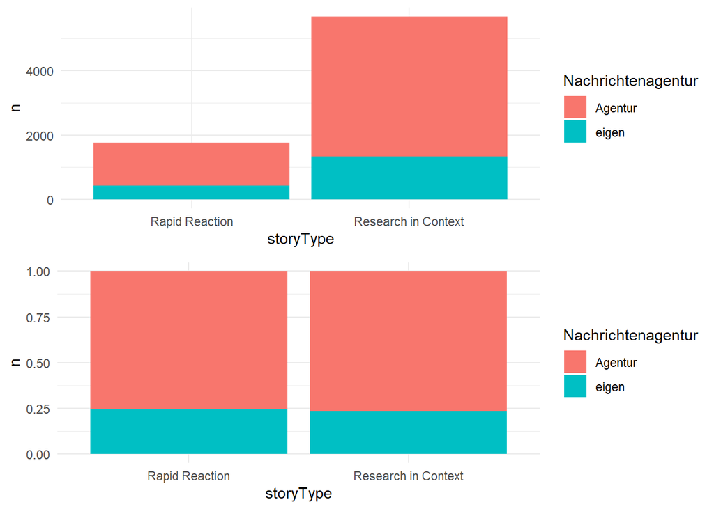

```r
plot1 <- tmp %>% ggplot(aes(fill = Nachrichtenagentur, y = n, x = storyType)) +
   geom_bar(position="stack", stat="identity")
plot2 <- tmp %>% ggplot(aes(fill = Nachrichtenagentur, y = n, x = storyType)) +
   geom_bar(position="fill", stat="identity")
grid.arrange(plot1, plot2, nrow=2)
```

##### Nach Ländern

Deutschland

```r
tmp <- left_join(reports, storyData, by = "storyNo") %>%
   filter(storyType %in% c("Research in Context", "Rapid Reaction"), Laendercode %in% c("DE", "AT", "CH")) %>%
   mutate(Nachrichtenagentur = if_else(modeOfUse == "indirekt via Nachrichtenagentur", "Agentur", "eigen")) %>%
   group_by(Laendercode, Nachrichtenagentur) %>% summarise(n = n())
tmp %>% pivot_wider(names_from = "Nachrichtenagentur", values_from = n) %>% kable()
```

| Laendercode | Agentur | eigen |
| --- | --- | --- |
| AT | 195 | 118 |
| CH | 217 | 137 |
| DE | 5188 | 1483 |

```r
tmp %>% group_by(Laendercode) %>% mutate(n = n / sum(n))%>% pivot_wider(names_from = "Nachrichtenagentur", values_from = n) %>% kable()
```

| Laendercode | Agentur | eigen |
| --- | --- | --- |
| AT | 0.6230032 | 0.3769968 |
| CH | 0.6129944 | 0.3870056 |
| DE | 0.7776945 | 0.2223055 |

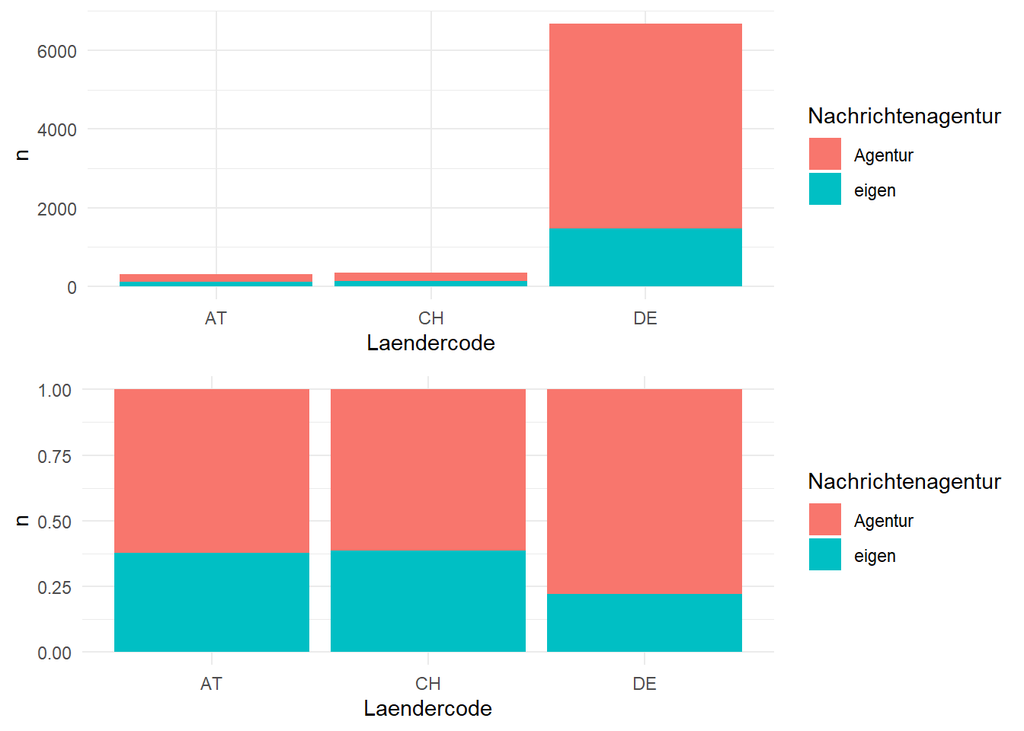

```r
plot1 <- tmp %>% ggplot(aes(fill = Nachrichtenagentur, y = n, x = Laendercode)) +
   geom_bar(position="stack", stat="identity")
plot2 <- tmp %>% ggplot(aes(fill = Nachrichtenagentur, y = n, x = Laendercode)) +
   geom_bar(position="fill", stat="identity")
grid.arrange(plot1, plot2, nrow=2)
```

#### F1.8 Wie lässt sich die Berichterstattung über neue Studienergebnisse mit SMCBeteiligung charakterisieren? Wie hoch ist die Diversität an Fachjournalen, welchen

Einfluss hat das Journal, welchen das Embargo?

##### Einfluss hat das Embargo auf Umfang und Kongruenz

```r
tmp <- storyData %>%
   filter(journal %in% embargo$journal) %>% left_join(embargo, by = "journal")
tmp2 <- reports %>% group_by(storyNo) %>% summarise(n = n())
tmp <- left_join(tmp, tmp2, by = "storyNo") %>% mutate(n = if_else(is.na(n), 0L, n))

cor(tmp$n, tmp$embargo, use = "complete.obs")
```

```
## [1] 0.1496463
```

##### Einfluss Journal

```r
tmp <- storyData %>%
   mutate(journal = if_else(journal == "Diabetes Care, Nature", "Diabetes Care", journal)) %>%
   mutate(journal = if_else(journal == "Science, Science Immunology", "Science", journal)) %>%
   filter(!(journal == "" | journal == "Old_Data_Import")) %>% left_join(embargo, by = "journal")
tmp2 <- reports %>% group_by(storyNo) %>% summarise(n = n())
tmp <- left_join(tmp, tmp2, by = "storyNo") %>% mutate(n = if_else(is.na(n), 0L, n))

tmp %>% group_by(journal) %>% summarise(nStorys = n(), max = max(n), mean = mean(n), median = median(n)) %>% arrange(desc(median)) %>% kable()
```

| journal | nStorys | max | mean | median |
| --- | --- | --- | --- | --- |
| Human Reproductive Update | 1 | 192 | 192.000000 | 192.0 |
| The Lancet Countdown | 1 | 157 | 157.000000 | 157.0 |
| Cell Metabolism | 2 | 168 | 102.500000 | 102.5 |
| Cochrane | 2 | 119 | 61.500000 | 61.5 |
| JNeurosci | 1 | 45 | 45.000000 | 45.0 |
| Nature Human Behaviour | 1 | 29 | 29.000000 | 29.0 |
| Nature Communications | 10 | 104 | 27.400000 | 22.5 |
| Environmental Science & Technology | 1 | 22 | 22.000000 | 22.0 |
| Nature Biotechnology | 1 | 21 | 21.000000 | 21.0 |
| The Lancet Psychiatry | 2 | 35 | 17.500000 | 17.5 |
| The Lancet Infectious Diseases | 2 | 25 | 16.500000 | 16.5 |
| PLOS Pathogens | 1 | 15 | 15.000000 | 15.0 |
| eNeuro | 1 | 14 | 14.000000 | 14.0 |
| Nature Ecology & Evolution | 3 | 23 | 13.000000 | 14.0 |
| The Lancet | 7 | 138 | 31.428571 | 14.0 |
| Current Biology | 2 | 23 | 12.000000 | 12.0 |
| Nature | 31 | 180 | 39.419355 | 12.0 |
| Nature Microbiology | 1 | 12 | 12.000000 | 12.0 |
| Annals of Internal Medicine | 4 | 34 | 14.250000 | 11.0 |
| Global Carbon Budget | 1 | 11 | 11.000000 | 11.0 |
| Nature Genetics | 3 | 16 | 9.333333 | 11.0 |
| NEJM | 6 | 28 | 12.666667 | 11.0 |
| JAMA | 2 | 19 | 10.000000 | 10.0 |
| The Lancet Oncology | 1 | 9 | 9.000000 | 9.0 |
| European Psychiatry | 1 | 7 | 7.000000 | 7.0 |
| JAMA Surgery | 1 | 7 | 7.000000 | 7.0 |
| Journal of the American College of Cardiology | 1 | 7 | 7.000000 | 7.0 |
| PNAS | 12 | 54 | 9.916667 | 6.0 |
| Stem Cell Reports | 2 | 6 | 5.500000 | 5.5 |
| Cell | 5 | 150 | 54.800000 | 5.0 |
| JAMA Oncology | 1 | 5 | 5.000000 | 5.0 |
| Nature Neuroscience | 1 | 5 | 5.000000 | 5.0 |
| Nature Plants | 1 | 5 | 5.000000 | 5.0 |
| Science | 37 | 121 | 16.810811 | 5.0 |
| Journal of Experimental Medicine | 1 | 4 | 4.000000 | 4.0 |
| Nature Energy | 3 | 5 | 3.666667 | 4.0 |
| Nature Medicine | 7 | 172 | 44.000000 | 4.0 |
| Nature Climate Change | 8 | 142 | 21.500000 | 3.5 |
| Science Advances | 2 | 6 | 3.500000 | 3.5 |
| JAMA Internal Medicine | 1 | 3 | 3.000000 | 3.0 |
| Nature Geoscience | 3 | 32 | 12.666667 | 3.0 |
| Nature Sustainability | 3 | 12 | 5.333333 | 3.0 |
| Pediatrics | 1 | 3 | 3.000000 | 3.0 |
| PLOS ONE | 3 | 215 | 72.666667 | 3.0 |
| Tobacco Control | 1 | 3 | 3.000000 | 3.0 |
| Science Translational Medicine | 4 | 11 | 4.500000 | 2.5 |
| Nature Biomedical Engineering | 1 | 2 | 2.000000 | 2.0 |
| Nature Machine Intelligence | 1 | 2 | 2.000000 | 2.0 |
| The Lancet Public Health | 1 | 2 | 2.000000 | 2.0 |
| Carbon Balance and Management | 1 | 1 | 1.000000 | 1.0 |
| Diabetes Care | 1 | 1 | 1.000000 | 1.0 |
| Frontiers in Behavioral Neuroscience | 1 | 1 | 1.000000 | 1.0 |
| Global Change Biology | 1 | 1 | 1.000000 | 1.0 |
| Joule | 1 | 1 | 1.000000 | 1.0 |
| Nature Food | 1 | 1 | 1.000000 | 1.0 |
| Neuron | 1 | 1 | 1.000000 | 1.0 |
| PLOS Biology | 3 | 7 | 2.666667 | 1.0 |
| The BMJ | 3 | 4 | 1.666667 | 1.0 |
| The Lancet Child and Adolescent Health | 1 | 1 | 1.000000 | 1.0 |
| The Lancet Neurology | 1 | 1 | 1.000000 | 1.0 |
| Cancer Research | 1 | 0 | 0.000000 | 0.0 |
| Cell Stem Cell | 1 | 0 | 0.000000 | 0.0 |
| Earth System Dynamics | 1 | 0 | 0.000000 | 0.0 |
| JAMA Psychiatry | 1 | 0 | 0.000000 | 0.0 |
| Nature Cell Biology | 1 | 0 | 0.000000 | 0.0 |
| One Earth | 1 | 0 | 0.000000 | 0.0 |
| Science Robotics | 1 | 0 | 0.000000 | 0.0 |

```r
tmp %>% group_by(journal) %>% summarise(nStorys = n(), mean = mean(n)) %>% arrange(desc(mean)) %>% filter(nStorys > 1) %>% kable()
```

| journal | nStorys | mean |
| --- | --- | --- |
| Cell Metabolism | 2 | 102.500000 |
| PLOS ONE | 3 | 72.666667 |
| Cochrane | 2 | 61.500000 |
| Cell | 5 | 54.800000 |
| Nature Medicine | 7 | 44.000000 |
| Nature | 31 | 39.419355 |
| The Lancet | 7 | 31.428571 |
| Nature Communications | 10 | 27.400000 |
| Nature Climate Change | 8 | 21.500000 |
| The Lancet Psychiatry | 2 | 17.500000 |
| Science | 37 | 16.810811 |
| The Lancet Infectious Diseases | 2 | 16.500000 |
| Annals of Internal Medicine | 4 | 14.250000 |
| Nature Ecology & Evolution | 3 | 13.000000 |
| Nature Geoscience | 3 | 12.666667 |
| NEJM | 6 | 12.666667 |
| Current Biology | 2 | 12.000000 |
| JAMA | 2 | 10.000000 |
| PNAS | 12 | 9.916667 |
| Nature Genetics | 3 | 9.333333 |
| Stem Cell Reports | 2 | 5.500000 |
| Nature Sustainability | 3 | 5.333333 |
| Science Translational Medicine | 4 | 4.500000 |
| Nature Energy | 3 | 3.666667 |
| Science Advances | 2 | 3.500000 |
| PLOS Biology | 3 | 2.666667 |
| The BMJ | 3 | 1.666667 |

```r
ImpactFactors <- read_csv2("Journale_ImpactFactor_nacherhoben_EXPORT_MH.csv")
```

```
## i Using "','" as decimal and "'.'" as grouping mark. Use `read_delim()` for more control.
```

```r
tmp3 <- tmp %>% group_by(journal) %>% summarise(nStorys = n(), max = max(n), mean = mean(n), median = median(n), nreports = sum(n)) %>%
   arrange(desc(median)) %>%
   left_join(ImpactFactors, by = "journal") %>%
   left_join(embargo, by = "journal") %>%
   select(-c("publisher", "embargoPublisher"))

tmp3 %>% kable()
```

| journal | nStorys | max | mean | median | nreports | 5-Jahres IF | embargo |
| --- | --- | --- | --- | --- | --- | --- | --- |
| Human Reproductive Update | 1 | 192 | 192.000000 | 192.0 | 192 | 14.480 | NA |
| The Lancet Countdown | 1 | 157 | 157.000000 | 157.0 | 157 | NA | NA |
| Cell Metabolism | 2 | 168 | 102.500000 | 102.5 | 205 | 24.290 | 633600s (~1.05 weeks) |
| Cochrane | 2 | 119 | 61.500000 | 61.5 | 123 | 7.970 | 131400s (~1.52 days) |
| JNeurosci | 1 | 45 | 45.000000 | 45.0 | 45 | 6.340 | 514800s (~5.96 days) |
| Nature Human Behaviour | 1 | 29 | 29.000000 | 29.0 | 29 | 12.320 | 502200s (~5.81 days) |
| Nature Communications | 10 | 104 | 27.400000 | 22.5 | 274 | 13.610 | 513000s (~5.94 days) |
| Environmental Science & Technology | 1 | 22 | 22.000000 | 22.0 | 22 | 8.540 | NA |
| Nature Biotechnology | 1 | 21 | 21.000000 | 21.0 | 21 | 42.300 | 502200s (~5.81 days) |
| The Lancet Psychiatry | 2 | 35 | 17.500000 | 17.5 | 35 | 18.810 | 180000s (~2.08 days) |
| The Lancet Infectious Diseases | 2 | 25 | 16.500000 | 16.5 | 33 | 22.950 | 172800s (~2 days) |
| PLOS Pathogens | 1 | 15 | 15.000000 | 15.0 | 15 | 6.480 | 597600s (~6.92 days) |
| eNeuro | 1 | 14 | 14.000000 | 14.0 | 14 | 3.544 | 514800s (~5.96 days) |
| Nature Ecology & Evolution | 3 | 23 | 13.000000 | 14.0 | 39 | 12.560 | 502200s (~5.81 days) |
| The Lancet | 7 | 138 | 31.428571 | 14.0 | 220 | 59.350 | 194400s (~2.25 days) |
| Current Biology | 2 | 23 | 12.000000 | 12.0 | 24 | 10.170 | 633600s (~1.05 weeks) |
| Nature | 31 | 180 | 39.419355 | 12.0 | 1222 | 46.490 | 516600s (~5.98 days) |
| Nature Microbiology | 1 | 12 | 12.000000 | 12.0 | 12 | 16.290 | 502200s (~5.81 days) |
| Annals of Internal Medicine | 4 | 34 | 14.250000 | 11.0 | 57 | 19.790 | 529200s (~6.12 days) |
| Global Carbon Budget | 1 | 11 | 11.000000 | 11.0 | 11 | NA | NA |
| Nature Genetics | 3 | 16 | 9.333333 | 11.0 | 28 | 30.330 | 502200s (~5.81 days) |
| NEJM | 6 | 28 | 12.666667 | 11.0 | 76 | 72.100 | 136800s (~1.58 days) |
| JAMA | 2 | 19 | 10.000000 | 10.0 | 20 | 47.680 | 439200s (~5.08 days) |
| The Lancet Oncology | 1 | 9 | 9.000000 | 9.0 | 9 | 35.840 | 180000s (~2.08 days) |
| European Psychiatry | 1 | 7 | 7.000000 | 7.0 | 7 | 4.770 | NA |
| JAMA Surgery | 1 | 7 | 7.000000 | 7.0 | 7 | 11.130 | 205200s (~2.38 days) |
| Journal of the American College of Cardiology | 1 | 7 | 7.000000 | 7.0 | 7 | 19.040 | 500400s (~5.79 days) |
| PNAS | 12 | 54 | 9.916667 | 6.0 | 119 | 10.620 | 345600s (~4 days) |
| Stem Cell Reports | 2 | 6 | 5.500000 | 5.5 | 11 | 6.630 | 633600s (~1.05 weeks) |
| Cell | 5 | 150 | 54.800000 | 5.0 | 274 | 38.620 | 633600s (~1.05 weeks) |
| JAMA Oncology | 1 | 5 | 5.000000 | 5.0 | 5 | 23.250 | 162000s (~1.88 days) |
| Nature Neuroscience | 1 | 5 | 5.000000 | 5.0 | 5 | 21.500 | 502200s (~5.81 days) |
| Nature Plants | 1 | 5 | 5.000000 | 5.0 | 5 | 14.580 | 502200s (~5.81 days) |
| Science | 37 | 121 | 16.810811 | 5.0 | 622 | 44.370 | 324000s (~3.75 days) |
| Journal of Experimental Medicine | 1 | 4 | 4.000000 | 4.0 | 4 | 11.980 | NA |
| Nature Energy | 3 | 5 | 3.666667 | 4.0 | 11 | 56.400 | 502200s (~5.81 days) |
| Nature Medicine | 7 | 172 | 44.000000 | 4.0 | 308 | 36.230 | 502200s (~5.81 days) |
| Nature Climate Change | 8 | 142 | 21.500000 | 3.5 | 172 | 24.310 | 502200s (~5.81 days) |
| Science Advances | 2 | 6 | 3.500000 | 3.5 | 7 | 14.090 | 324000s (~3.75 days) |
| JAMA Internal Medicine | 1 | 3 | 3.000000 | 3.0 | 3 | 19.660 | 356400s (~4.12 days) |
| Nature Geoscience | 3 | 32 | 12.666667 | 3.0 | 38 | 16.103 | 502200s (~5.81 days) |
| Nature Sustainability | 3 | 12 | 5.333333 | 3.0 | 16 | 12.090 | 502200s (~5.81 days) |
| Pediatrics | 1 | 3 | 3.000000 | 3.0 | 3 | 6.450 | 579600s (~6.71 days) |
| PLOS ONE | 3 | 215 | 72.666667 | 3.0 | 218 | 3.230 | 594000s (~6.88 days) |
| Tobacco Control | 1 | 3 | 3.000000 | 3.0 | 3 | 6.350 | 248400s (~2.88 days) |
| Science Translational Medicine | 4 | 11 | 4.500000 | 2.5 | 18 | 18.560 | 230400s (~2.67 days) |
| Nature Biomedical Engineering | 1 | 2 | 2.000000 | 2.0 | 2 | 18.950 | 502200s (~5.81 days) |
| Nature Machine Intelligence | 1 | 2 | 2.000000 | 2.0 | 2 | NA | 502200s (~5.81 days) |
| The Lancet Public Health | 1 | 2 | 2.000000 | 2.0 | 2 | 16.710 | 172800s (~2 days) |
| Carbon Balance and Management | 1 | 1 | 1.000000 | 1.0 | 1 | 3.930 | NA |
| Diabetes Care | 1 | 1 | 1.000000 | 1.0 | 1 | 13.050 | NA |
| Frontiers in Behavioral Neuroscience | 1 | 1 | 1.000000 | 1.0 | 1 | 3.320 | NA |
| Global Change Biology | 1 | 1 | 1.000000 | 1.0 | 1 | 2.610 | NA |
| Joule | 1 | 1 | 1.000000 | 1.0 | 1 | 27.060 | 507600s (~5.88 days) |
| Nature Food | 1 | 1 | 1.000000 | 1.0 | 1 | NA | 502200s (~5.81 days) |
| Neuron | 1 | 1 | 1.000000 | 1.0 | 1 | 16.000 | 464400s (~5.38 days) |
| PLOS Biology | 3 | 7 | 2.666667 | 1.0 | 8 | 8.880 | 608400s (~1.01 weeks) |
| The BMJ | 3 | 4 | 1.666667 | 1.0 | 5 | 28.000 | NA |
| The Lancet Child and Adolescent Health | 1 | 1 | 1.000000 | 1.0 | 1 | 8.540 | 151200s (~1.75 days) |
| The Lancet Neurology | 1 | 1 | 1.000000 | 1.0 | 1 | 31.500 | 133200s (~1.54 days) |
| Cancer Research | 1 | 0 | 0.000000 | 0.0 | 0 | 9.880 | 291600s (~3.38 days) |
| Cell Stem Cell | 1 | 0 | 0.000000 | 0.0 | 0 | 23.450 | 633600s (~1.05 weeks) |
| Earth System Dynamics | 1 | 0 | 0.000000 | 0.0 | 0 | 4.140 | NA |
| JAMA Psychiatry | 1 | 0 | 0.000000 | 0.0 | 0 | 18.330 | 180000s (~2.08 days) |
| Nature Cell Biology | 1 | 0 | 0.000000 | 0.0 | 0 | 21.000 | 502200s (~5.81 days) |
| One Earth | 1 | 0 | 0.000000 | 0.0 | 0 | NA | 594000s (~6.88 days) |
| Science Robotics | 1 | 0 | 0.000000 | 0.0 | 0 | 20.130 | 230400s (~2.67 days) |

```r
cor(tmp3$nStorys, tmp3$embargo, use = "complete.obs")
```

```
## [1] -0.001818914
```

```r
cor(tmp3$nreports, tmp3$embargo, use = "complete.obs")
```

```
## [1] 0.09825517
```

```r
cor(tmp3$nStorys, tmp3$`5-Jahres IF`, use = "complete.obs")
```

```
## [1] 0.4020817
```

```r
cor(tmp3$nreports, tmp3$`5-Jahres IF`, use = "complete.obs")
```

```
## [1] 0.375997
```

### F2 Wie schlägt sich durch das SMC bereitgestelltes Material in der Wissenschaftsberichterstattung von kongruent aufgegriffenen Anlässen nieder?

#### F2.1 Wie ist ein typischer Beitrag hinsichtlich Länge, prozentualem Anteil von SMC-Material, dessen Position und Quellennennung aufgebaut? Gibt es Unterschiede zwischen den Mediengattungen und den verschiedenen Anlasstypen?

##### Länge der Beiträge gesamt

```r
Inhaltsanalyse %>%
   summarise(mean = mean(Laenge_Beitrag), min = min(Laenge_Beitrag), Q1 = quantile(Laenge_Beitrag, 0.25),
             median = median(Laenge_Beitrag), Q3 = quantile(Laenge_Beitrag, 0.75), max = max(Laenge_Beitrag)) %>% kable(digits = 3)
```

| mean | min | Q1 | median | Q3 | max |
| --- | --- | --- | --- | --- | --- |
| 566.64 | 30 | 343.25 | 520 | 675 | 2251 |

##### Länge der Beiträge SMC

```r
Inhaltsanalyse %>% filter(!Kontrolle) %>%
   summarise(mean = mean(Laenge_Beitrag), min = min(Laenge_Beitrag), Q1 = quantile(Laenge_Beitrag, 0.25),
             median = median(Laenge_Beitrag), Q3 = quantile(Laenge_Beitrag, 0.75), max = max(Laenge_Beitrag)) %>% kable(digits = 3)
```

| mean | min | Q1 | median | Q3 | max |
| --- | --- | --- | --- | --- | --- |
| 670.74 | 69 | 460.5 | 612 | 855.25 | 2251 |

##### Länge der Beiträge Online / Print

```r
Inhaltsanalyse %>% group_by(Mediengattung) %>%
   summarise(mean = mean(Laenge_Beitrag), min = min(Laenge_Beitrag), Q1 = quantile(Laenge_Beitrag, 0.25),
             median = median(Laenge_Beitrag), Q3 = quantile(Laenge_Beitrag, 0.75), max = max(Laenge_Beitrag), n = n()) %>% kable(digits = 3)
```

| Mediengattung | mean | min | Q1 | median | Q3 | max | n |
| --- | --- | --- | --- | --- | --- | --- | --- |
| Nachrichtenagentur | 522.357 | 272 | 360.5 | 578 | 637.25 | 818 | 14 |
| Online | 594.351 | 144 | 383.5 | 526 | 681.50 | 2251 | 111 |
| Print | 534.081 | 30 | 314.5 | 460 | 669.00 | 1595 | 74 |
| NA | 520.000 | 520 | 520.0 | 520 | 520.00 | 520 | 1 |

```r
Inhaltsanalyse %>% left_join(storyData, by = c(id_global = "storyNo")) %>% group_by(storyType) %>%
   summarise(mean = mean(Laenge_Beitrag), min = min(Laenge_Beitrag), Q1 = quantile(Laenge_Beitrag, 0.25),
             median = median(Laenge_Beitrag), Q3 = quantile(Laenge_Beitrag, 0.75), max = max(Laenge_Beitrag), n = n()) %>% kable(digits = 3)
```

| storyType | mean | min | Q1 | median | Q3 | max | n |
| --- | --- | --- | --- | --- | --- | --- | --- |
| Rapid Reaction | 546.889 | 69 | 328 | 560.0 | 798.0 | 866 | 9 |
| Research in Context | 682.989 | 180 | 466 | 613.0 | 859.5 | 2251 | 91 |
| NA | 462.540 | 30 | 280 | 382.5 | 540.5 | 2135 | 100 |

##### Anteil SMC-Material in den Fällen

```r
Inhaltsanalyse %>% filter(!Kontrolle) %>%
   mutate(SMC_Anteil = Laenge_SMC_Material / Laenge_Beitrag) %>%
   summarise(mean = mean(SMC_Anteil), min = min(SMC_Anteil), Q1 = quantile(SMC_Anteil, 0.25), median = median(SMC_Anteil), Q3 = quantile(SMC_Anteil, 0.75), max = max(SMC_Anteil)) %>% kable(digits = 3)
```

| mean | min | Q1 | median | Q3 | max |
| --- | --- | --- | --- | --- | --- |
| 0.168 | 0.004 | 0.098 | 0.157 | 0.225 | 0.47 |

##### Position SMC-Material

```r
Inhaltsanalyse %>% filter(!Kontrolle) %>% group_by(Position_SMC_Material) %>% summarise(n = n(), rel = n()/100)
```

```
## # A tibble: 4 x 3
##   Position_SMC_Material                  n   rel
##   <chr>                              <int> <dbl>
## 1 eher im hinteren Teil des Beitrags    64  0.64
## 2 eher im vorderen Teil des Beitrags     4  0.04
## 3 eher mittig                           14  0.14
## 4 gleichmäßig verteilt                  18  0.18
```

```r
Inhaltsanalyse %>% filter(!Kontrolle) %>% left_join(storyData, by = c(id_global = "storyNo")) %>%
   group_by(storyType, Position_SMC_Material) %>% summarise(n = n(), rel = n()/100)
```

```
## # A tibble: 7 x 4
## # Groups:   storyType [2]
##   storyType           Position_SMC_Material                  n   rel
##   <chr>               <chr>                              <int> <dbl>
## 1 Rapid Reaction      eher im hinteren Teil des Beitrags     4  0.04
## 2 Rapid Reaction      eher im vorderen Teil des Beitrags     1  0.01
## 3 Rapid Reaction      eher mittig                            4  0.04
## 4 Research in Context eher im hinteren Teil des Beitrags    60  0.6
## 5 Research in Context eher im vorderen Teil des Beitrags     3  0.03
## 6 Research in Context eher mittig                           10  0.1
## 7 Research in Context gleichmäßig verteilt                  18  0.18
```

##### Nennung SMC

```r
Inhaltsanalyse %>% filter(!Kontrolle) %>% group_by(SMC_als_Quelle) %>% summarise(n = n(), rel = n()/100)
```

```
## # A tibble: 2 x 3
##   SMC_als_Quelle     n   rel
##   <chr>          <int> <dbl>
## 1 ja                 7  0.07
## 2 nein              93  0.93
```

```r
Inhaltsanalyse %>% filter(!Kontrolle) %>% left_join(storyData, by = c(id_global = "storyNo")) %>%
   group_by(SMC_als_Quelle, Position_SMC_Material) %>% summarise(n = n(), rel = n()/100)
```

```
## # A tibble: 7 x 4
## # Groups:   SMC_als_Quelle [2]
##   SMC_als_Quelle Position_SMC_Material                  n   rel
##   <chr>          <chr>                              <int> <dbl>
## 1 ja             eher im hinteren Teil des Beitrags     3  0.03
## 2 ja             eher mittig                            2  0.02
## 3 ja             gleichmäßig verteilt                   2  0.02
## 4 nein           eher im hinteren Teil des Beitrags    61  0.61
## 5 nein           eher im vorderen Teil des Beitrags     4  0.04
## 6 nein           eher mittig                           12  0.12
## 7 nein           gleichmäßig verteilt                  16  0.16
```

##### Zu F3.1: Zitatanteil Fälle vs Kontrollen

```r
expertsIA %>% group_by(id) %>% summarise(sumZitatlaenge = sum(Zitatlaenge)) %>% left_join(Inhaltsanalyse, by = "id") %>%
   mutate(SMC_Anteil = sumZitatlaenge / Laenge_Beitrag) %>% group_by(Kontrolle) %>%
   summarise(mean = mean(SMC_Anteil), min = min(SMC_Anteil), Q1 = quantile(SMC_Anteil, 0.25), median = median(SMC_Anteil), Q3 = quantile(SMC_Anteil, 0.75), max = max(SMC_Anteil)) %>% kable(digits = 3)
```

| Kontrolle | mean | min | Q1 | median | Q3 | max |
| --- | --- | --- | --- | --- | --- | --- |
| FALSE | 0.215 | 0.019 | 0.135 | 0.217 | 0.280 | 0.493 |
| TRUE | 0.164 | 0.017 | 0.103 | 0.160 | 0.206 | 0.472 |

```r
tmp <- expertsIA %>% group_by(id) %>% summarise(sumZitatlaenge = sum(Zitatlaenge)) %>% left_join(Inhaltsanalyse, by = "id") %>%
   #mutate(SMC_Anteil = sumZitatlaenge / Laenge_Beitrag) %>%
   group_by(Kontrolle) %>% summarise(x = sum(sumZitatlaenge), n = sum(Laenge_Beitrag)) %>% mutate(p = x/n)
fisher.test(tmp[1:2,2:3])
```

```
##
##  Fisher's Exact Test for Count Data
##
## data:  tmp[1:2, 2:3]
## p-value < 2.2e-16
## alternative hypothesis: true odds ratio is not equal to 1
## 95 percent confidence interval:
##  1.289847 1.392956
## sample estimates:
## odds ratio
##   1.340301
```

```r
tmp <- expertsIA %>% group_by(id) %>% summarise(sumZitatlaenge = sum(Zitatlaenge)) %>% left_join(Inhaltsanalyse, by = "id") %>%
   mutate(SMC_Anteil = sumZitatlaenge / Laenge_Beitrag)

t.test(y = tmp$SMC_Anteil[tmp$Kontrolle], x = tmp$SMC_Anteil[!tmp$Kontrolle])
```

```
##
##  Welch Two Sample t-test
##
## data:  tmp$SMC_Anteil[!tmp$Kontrolle] and tmp$SMC_Anteil[tmp$Kontrolle]
## t = 2.8959, df = 100.34, p-value = 0.004641
## alternative hypothesis: true difference in means is not equal to 0
## 95 percent confidence interval:
##  0.01615128 0.08641988
## sample estimates:
## mean of x mean of y
## 0.2150125 0.1637269
```

```r
sd(tmp$SMC_Anteil[tmp$Kontrolle])
```

```
## [1] 0.09438714
```

```r
sd(tmp$SMC_Anteil[!tmp$Kontrolle])
```

```
## [1] 0.1089793
```

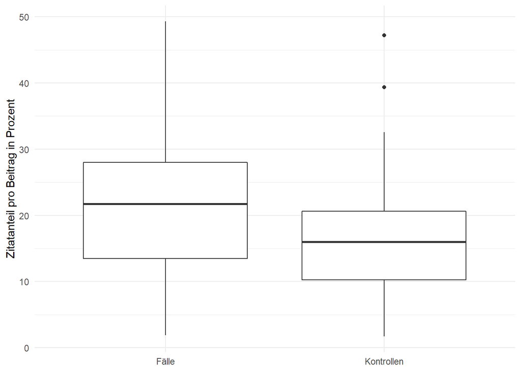

```r
plot1 <- expertsIA %>% group_by(id) %>% summarise(sumZitatlaenge = sum(Zitatlaenge)) %>% left_join(Inhaltsanalyse, by = "id") %>%
   mutate(SMC_Anteil = sumZitatlaenge / Laenge_Beitrag,
          Kontrolle_label = if_else(Kontrolle, "Kontrollen", "Fälle")) %>%
   ggplot(aes(y = SMC_Anteil*100, x = Kontrolle_label)) +
   geom_boxplot() +
   scale_color_brewer(type = "qual", palette = "Set1") +
   ylab("Zitatanteil pro Beitrag in Prozent") +
   theme(legend.title = element_blank()) +
   scale_x_discrete(name = NULL)


plot1
```

```r
ggsave(filename = "p21_Zitatlaenge.png", plot = plot1, device = "png", width = 150, height = 150, scale = scale_glob, units = "mm")
```

##### Zitatlänge SMC-vermittelt

```r
expertsIA %>% group_by(SMC_verm) %>%
   summarise(mean = mean(Zitatlaenge), min = min(Zitatlaenge), Q1 = quantile(Zitatlaenge, 0.25), median = median(Zitatlaenge), Q3 = quantile(Zitatlaenge, 0.75), max = max(Zitatlaenge)) %>% kable(digits = 3)
```

| SMC_verm | mean | min | Q1 | median | Q3 | max |
| --- | --- | --- | --- | --- | --- | --- |
| ja | 51.037 | 2 | 29.0 | 45 | 66 | 202 |
| nein | 46.920 | 7 | 22.5 | 38 | 60 | 260 |

##### Expert*innen Länder

```r
expertsIA %>% group_by(Land) %>% summarise(n = n()) %>% kable()
```

| Land | n |
| --- | --- |
| andere Länder in Europa | 38 |
| China | 12 |
| Deutschland | 222 |
| Österreich | 15 |
| Schweiz | 23 |
| Sonstige | 11 |
| USA | 39 |

```r
expertsIA %>% group_by(Land, SMC_verm) %>% summarise(n = n()) %>% pivot_wider(names_from = SMC_verm, values_from = n) %>% kable()
```

| Land | ja | nein |
| --- | --- | --- |
| andere Länder in Europa | 15 | 23 |
| China | NA | 12 |
| Deutschland | 129 | 93 |
| Österreich | 9 | 6 |
| Schweiz | 6 | 17 |
| Sonstige | NA | 11 |
| USA | 2 | 37 |

```r
expertsIA %>% group_by(Land, SMC_verm) %>% summarise(n = n()) %>% group_by(SMC_verm) %>%
   mutate(rel = n/sum(n, na.rm = TRUE)) %>% select(-n) %>%  pivot_wider(names_from = SMC_verm, values_from = rel) %>% kable(digits = 3)
```

| Land | ja | nein |
| --- | --- | --- |
| andere Länder in Europa | 0.093 | 0.116 |
| China | NA | 0.060 |
| Deutschland | 0.801 | 0.467 |
| Österreich | 0.056 | 0.030 |
| Schweiz | 0.037 | 0.085 |
| Sonstige | NA | 0.055 |
| USA | 0.012 | 0.186 |

##### Zu F3.3: unbeteiligte Expert*innen Anzahl

```r
expertsIA %>% group_by(Kontrolle) %>% filter(Beteiligung == "unbeteiligt") %>% summarise(n = n()) %>% kable()
```

| Kontrolle | n |
| --- | --- |
| FALSE | 63 |
| TRUE | 16 |

```r
tmp <- expertsIA %>% group_by(id, Kontrolle) %>% filter(Beteiligung == "unbeteiligt") %>% summarise(n = n())
table(tmp[tmp$Kontrolle,]$n)
```

```
##
##  1
## 16
```

```r
table(tmp[!tmp$Kontrolle,]$n)
```

```
##
##  1
## 63
```

Häufigkeitstabelle Anzahl unbeteiligte Expert*innen Kontrollen

```r
table(c(tmp[tmp$Kontrolle,]$n, rep(0, 100-length(tmp[tmp$Kontrolle,]$n))))
```

```
##
##  0  1
## 84 16
```

Häufigkeitstabelle Anzahl unbeteiligte Expert*innen Fälle

```r
table(c(tmp[!tmp$Kontrolle,]$n, rep(0, 100-length(tmp[!tmp$Kontrolle,]$n))))
```

```
##
##  0  1
## 37 63
```

##### Zu F3.3 unbeteiligte vs beteiligte Expert*innen Anzahl Worte

Wichtig: Hier ist die Grundgesamtheit die Gesamtheit der Expert*innen. Da es ja auch viele Beiträge ohne unbeteiligte Expert*innen gibt und die Zahl der Expert*innen pro Text unterschiedlich ist, sind keine Aussagen auf Text-Ebene möglich.

```r
expertsIA %>% group_by(Kontrolle, Beteiligung) %>% summarise(`mittlere Zahl Wörter` = mean(Zitatlaenge)) %>% kable(digits = 0)
```

| Kontrolle | Beteiligung | mittlere Zahl Wörter |
| --- | --- | --- |
| FALSE | beteiligt | 46 |
| FALSE | unbeteiligt | 58 |
| FALSE | NA | 45 |
| TRUE | beteiligt | 44 |
| TRUE | unbeteiligt | 72 |
| TRUE | NA | 48 |

Hier jetzt die Betrachtung auf Text-Ebene. Texte ohne unbeteiligte Expert*innen werden hier mit 0 mitgezählt.

```r
expertsIA %>% group_by(Kontrolle, Beteiligung) %>% summarise(`Zahl Wörter` = sum(Zitatlaenge)/100) %>% kable(digits = 0)
```

| Kontrolle | Beteiligung | Zahl Wörter |
| --- | --- | --- |
| FALSE | beteiligt | 17 |
| FALSE | unbeteiligt | 36 |
| FALSE | NA | 83 |
| TRUE | beteiligt | 13 |
| TRUE | unbeteiligt | 11 |
| TRUE | NA | 15 |

##### Zu F3.3: Anzahl SMC vs nicht SMC Expert*innen

```r
expertsIA %>% filter(!Kontrolle) %>% group_by(SMC_verm) %>% summarise(n = n()) %>% kable(digits = 0)
```

| SMC_verm | n |
| --- | --- |
| ja | 161 |
| nein | 122 |

##### Zu F3.3: Expert*innen nach Land

Kontrollen

```r
tmp <- table(expertsIA$Land[expertsIA$Kontrolle])
tibble(Land = names(tmp), n = as.integer(tmp)) %>% mutate(Anteil = n / sum(n)) %>% kable(digits = 1)
```

| Land | n | Anteil |
| --- | --- | --- |
| andere Länder in Europa | 5 | 0.1 |
| Deutschland | 39 | 0.5 |
| Österreich | 6 | 0.1 |
| Schweiz | 2 | 0.0 |
| Sonstige | 7 | 0.1 |
| USA | 18 | 0.2 |

Fälle

```r
tmp <- table(expertsIA$Land[!expertsIA$Kontrolle])
tibble(Land = names(tmp), n = as.integer(tmp)) %>% mutate(Anteil = n / sum(n)) %>% kable(digits = 1)
```

| Land | n | Anteil |
| --- | --- | --- |
| andere Länder in Europa | 33 | 0.1 |
| China | 12 | 0.0 |
| Deutschland | 183 | 0.6 |
| Österreich | 9 | 0.0 |
| Schweiz | 21 | 0.1 |
| Sonstige | 4 | 0.0 |
| USA | 21 | 0.1 |

##### Länge der Artikel mit SMC (Fälle) – Online/Print

```r
Inhaltsanalyse %>%
   filter(!Kontrolle) %>%
   group_by(Mediengattung) %>%
   summarise(mean = mean(Laenge_Beitrag), min = min(Laenge_Beitrag), Q1 = quantile(Laenge_Beitrag, 0.25),
             median = median(Laenge_Beitrag), Q3 = quantile(Laenge_Beitrag, 0.75), max = max(Laenge_Beitrag), n = n()) %>%
   kable(digits = 3)
```

| Mediengattung | mean | min | Q1 | median | Q3 | max | n |
| --- | --- | --- | --- | --- | --- | --- | --- |
| Nachrichtenagentur | 536.846 | 272 | 440.0 | 596 | 647.0 | 818 | 13 |
| Online | 702.078 | 180 | 474.5 | 611 | 859.5 | 2251 | 51 |
| Print | 679.114 | 69 | 460.0 | 659 | 893.0 | 1248 | 35 |
| NA | 520.000 | 520 | 520.0 | 520 | 520.0 | 520 | 1 |

##### Anteil SMC-Material in Online/Print der Fälle

```r
Inhaltsanalyse %>%
   filter(!Kontrolle) %>%
   group_by(Mediengattung) %>%
   mutate(SMC_Anteil = Laenge_SMC_Material / Laenge_Beitrag) %>%
   summarise(mean = mean(SMC_Anteil), min = min(SMC_Anteil), Q1 = quantile(SMC_Anteil, 0.25),
             median = median(SMC_Anteil), Q3 = quantile(SMC_Anteil, 0.75), max = max(SMC_Anteil)) %>%
   kable(digits = 3)
```

| Mediengattung | mean | min | Q1 | median | Q3 | max |
| --- | --- | --- | --- | --- | --- | --- |
| Nachrichtenagentur | 0.186 | 0.029 | 0.109 | 0.155 | 0.282 | 0.459 |
| Online | 0.183 | 0.026 | 0.111 | 0.168 | 0.232 | 0.470 |
| Print | 0.136 | 0.004 | 0.069 | 0.123 | 0.211 | 0.377 |
| NA | 0.352 | 0.352 | 0.352 | 0.352 | 0.352 | 0.352 |

##### Zu F3.3: Mittlere Zitatlänge beteiligt vs unbeteiligt

```r
expertsIA %>% group_by(Beteiligung) %>% summarise(`mittlere Zahl Wörter` = mean(Zitatlaenge)) %>% kable(digits = 0)
```

| Beteiligung | mittlere Zahl Wörter |
| --- | --- |
| beteiligt | 45 |
| unbeteiligt | 61 |
| NA | 46 |

##### Expertys Geschlecht Fall / Kontrolle

```r
expertsIA %>% group_by(Kontrolle, Geschlecht) %>% summarise(n = n()) %>% pivot_wider(names_from = Geschlecht, values_from = n) %>% kable()
```

| Kontrolle | männlich | weiblich | NA |
| --- | --- | --- | --- |
| FALSE | 79 | 20 | 184 |
| TRUE | 34 | 12 | 31 |

##### Expertys Zitatlängen

```r
expertsIA %>% group_by(Kontrolle) %>%
   summarise(mean = mean(Zitatlaenge), min = min(Zitatlaenge), Q1 = quantile(Zitatlaenge, 0.25), median = median(Zitatlaenge), Q3 = quantile(Zitatlaenge, 0.75), max = max(Zitatlaenge)) %>% kable(digits = 3)
```

| Kontrolle | mean | min | Q1 | median | Q3 | max |
| --- | --- | --- | --- | --- | --- | --- |
| FALSE | 48.120 | 2 | 26 | 41 | 63 | 236 |
| TRUE | 51.117 | 7 | 26 | 41 | 61 | 260 |

#### F2.2 Welchen Einfluss hat der Umfang von SMC-Angeboten und Länge der Expertenstatements auf die Verwendung?

##### Story-Ebene

keine größeren Korrelationen auf Story-Ebene

```r
tmp <- citations %>%
   filter(storyNo %in% Stamm_Faelle$storyNo) %>%
   group_by(storyNo) %>%
   summarise(Expertentreffer = n())
tmp <- Stamm_Faelle %>%
   select(storyNo, Gesamtlaenge_SMC_story, Laenge_Teaser) %>%
   distinct() %>%
   left_join(tmp, by = "storyNo")
cor(tmp$Gesamtlaenge_SMC_story, tmp$Laenge_Teaser)
```

```
## [1] -0.03599955
```

```r
cor(tmp$Gesamtlaenge_SMC_story, tmp$Expertentreffer)
```

```
## [1] -0.07230931
```

```r
cor(tmp$Laenge_Teaser, tmp$Expertentreffer)
```

```
## [1] -0.2874079
```

```r
tmp <- reports %>%
   filter(storyNo %in% Stamm_Faelle$storyNo) %>%
   group_by(storyNo) %>%
   summarise(Anzahl_reports = n())
tmp <- Stamm_Faelle %>%
   select(storyNo, Gesamtlaenge_SMC_story, Laenge_Teaser) %>%
   distinct() %>%
   left_join(tmp, by = "storyNo")
cor(tmp$Gesamtlaenge_SMC_story, tmp$Anzahl_reports)
```

```
## [1] -0.1130054
```

```r
cor(tmp$Laenge_Teaser, tmp$Anzahl_reports)
```

```
## [1] -0.04898905
```

##### Expert*innen-Ebene

Kein globaler Effekt:

```r
tmp <- citations %>% filter(storyNo %in% Stamm_Faelle$storyNo) %>% group_by(storyNo, civiId) %>% summarise(Expertentreffer = n())
tmp2 <- experts %>% select(storyNo, id, displayName, contactId)
tmp <- left_join(tmp, tmp2, by = c("storyNo", civiId = "contactId")) %>% arrange(storyNo, id)
tmp <- left_join(Stamm_Faelle, tmp, by = c("storyNo", Name_Expert = "displayName")) %>% mutate(Expertentreffer = if_else(is.na(Expertentreffer), 0L, Expertentreffer))

cor(tmp$Laenge_Statement, tmp$Expertentreffer)
```

```
## [1] 0.0509773
```

Auch innerhalb der Storys zeigt sich kein eindeutiges Bild.

```r
tmp %>% group_by(storyNo) %>% summarise(cor = cor(Laenge_Statement, Expertentreffer)) %>% kable()
```

| storyNo | cor |
| --- | --- |
| 17030 | -0.3127536 |
| 17052 | -0.6924145 |
| 17053 | 0.1864308 |
| 17067 | 0.6511703 |
| 17069 | 0.9246844 |
| 18005 | 0.4696964 |
| 18019 | 1.0000000 |
| 18020 | -0.8752619 |
| 18026 | -0.6048078 |
| 18027 | -0.5353760 |
| 18028 | 0.6547487 |
| 18033 | 0.6410045 |
| 18040 | 0.7322065 |
| 18075 | -1.0000000 |
| 18079 | 0.3332832 |
| 18081 | NA |
| 18093 | -0.2252001 |
| 18096 | -0.1284360 |
| 19012 | 0.4390650 |
| 19018 | -0.2029113 |
| 19044 | 0.9728760 |
| 19048 | 0.3762025 |
| 19058 | 0.0820364 |
| 19063 | -0.1802525 |
| 19065 | 0.0289601 |
| 19067 | -0.6722020 |
| 19080 | 0.1024005 |
| 19086 | 0.5508668 |
| 19088 | -0.9911533 |
| 19127 | -0.4056879 |

### F3 Wie unterscheidet sich die Wissenschaftsberichterstattung zwischen kongruent berichteten Anlässen mit SMC-Beteiligung und ohne?

#### F3.1 Welche formalen Unterschiede hinsichtlich Länge des Artikels, Urheber und

verantwortlichem Ressort gibt es?

##### Länge des Beitrags

```r
Inhaltsanalyse %>% group_by(Kontrolle) %>%
   summarise(mean = mean(Laenge_Beitrag), min = min(Laenge_Beitrag),
             Q1 = quantile(Laenge_Beitrag, 0.25), median = median(Laenge_Beitrag),
             Q3 = quantile(Laenge_Beitrag, 0.75), max = max(Laenge_Beitrag)) %>% kable(digits = 3)
```

| Kontrolle | mean | min | Q1 | median | Q3 | max |
| --- | --- | --- | --- | --- | --- | --- |
| FALSE | 670.74 | 69 | 460.5 | 612.0 | 855.25 | 2251 |
| TRUE | 462.54 | 30 | 280.0 | 382.5 | 540.50 | 2135 |

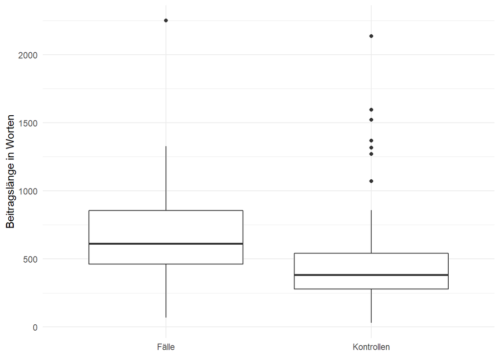

```r
plot1 <- Inhaltsanalyse %>%
   mutate(Kontrolle_label = if_else(Kontrolle, "Kontrollen", "Fälle")) %>%
   ggplot(aes(y = Laenge_Beitrag, x = Kontrolle_label)) +
   geom_boxplot() +
   scale_color_brewer(type = "qual", palette = "Set1") +
   ylab("Beitragslänge in Worten") +
   theme(legend.title = element_blank()) +
   scale_x_discrete(name = NULL)


plot1
```

```r
ggsave(filename = "p31_Beitragslaenge.png", plot = plot1, device = "png", width = 150, height = 150, scale = scale_glob, units = "mm")
```

##### Urheber*in

```r
Inhaltsanalyse %>% group_by(Kontrolle, UrheberIn) %>%
   summarise(n = n()) %>% pivot_wider(names_from = UrheberIn, values_from = n) %>% kable()
```

| Kontrolle | - | Beteiligung Nachrichtenagentur | Redaktion/ (red) | rein Journalist*in | rein Nachrichtenagentur | NA |
| --- | --- | --- | --- | --- | --- | --- |
| FALSE | 7 | 5 | 1 | 59 | 26 | 2 |
| TRUE | 6 | 11 | 1 | 50 | 32 | NA |

##### Nachrichtenagentur

```r
Inhaltsanalyse %>% group_by(Kontrolle, Nachrichtenagentur1) %>%
   summarise(n = n()) %>% pivot_wider(names_from = Nachrichtenagentur1, values_from = n) %>% kable()
```

| Kontrolle | dpa | DPA | SDA | NA | AFP | AP |
| --- | --- | --- | --- | --- | --- | --- |
| FALSE | 1 | 27 | 2 | 70 | NA | NA |
| TRUE | NA | 36 | 1 | 56 | 6 | 1 |

##### Ressort

```r
Inhaltsanalyse %>% group_by(Ressort, Kontrolle) %>% summarise(n = n()) %>% pivot_wider(names_from = "Ressort", values_from = "n") %>% kable()
```

| Kontrolle | Gesundheit/Medizin | Kultur/Feuilleton | Nachrichten/Aktuelles | Panorama/Lifestyle | Politik | Sonstige | Technik/Digital | Wirtschaft | Wissenschaft | NA |
| --- | --- | --- | --- | --- | --- | --- | --- | --- | --- | --- |
| FALSE | 5 | NA | 10 | 2 | NA | 5 | 1 | NA | 24 | 53 |
| TRUE | 7 | 1 | 10 | 8 | 7 | 5 | 2 | 6 | 23 | 31 |

```r
tmp <- bind_rows(Stamm_Faelle, Stamm_Kontrollen) %>% select(storyNo, Anlasstyp) %>% distinct()
tmp2 <- Inhaltsanalyse %>%
   mutate(id_global = if_else(is.na(as.numeric(id_global)), str_extract(Inhaltsanalyse$id_global, pattern = "K[0-9]"), id_global))
left_join(tmp2, tmp, by = c("id_global" = "storyNo")) %>%
   group_by(Anlasstyp) %>% summarise(n = n()) %>% kable()
```

| Anlasstyp | n |
| --- | --- |
| aktuell, nicht wissenschaftsgeneriert | 52 |
| aktuell, wissenschaftsgeneriert | 148 |

```r
tmp <- bind_rows(Stamm_Faelle, Stamm_Kontrollen) %>% select(storyNo, Anlasstyp) %>% distinct()
tmp2 <- Inhaltsanalyse %>% mutate(id_global = if_else(is.na(as.numeric(id_global)), str_extract(Inhaltsanalyse$id_global, pattern = "K[0-9]"), id_global))
left_join(tmp2, tmp, by = c("id_global" = "storyNo")) %>%
   group_by(Kontrolle, Anlasstyp) %>%
   summarise(mean = mean(Laenge_Beitrag),
             min = min(Laenge_Beitrag),
             Q1 = quantile(Laenge_Beitrag, 0.25),
             median = median(Laenge_Beitrag),
             Q3 = quantile(Laenge_Beitrag, 0.75),
             max = max(Laenge_Beitrag), n = n()) %>%
   kable()
```

| Kontrolle | Anlasstyp | mean | min | Q1 | median | Q3 | max | n |
| --- | --- | --- | --- | --- | --- | --- | --- | --- |
| FALSE | aktuell, nicht wissenschaftsgeneriert | 568.5000 | 69 | 346.50 | 664.5 | 846.00 | 866 | 6 |
| FALSE | aktuell, wissenschaftsgeneriert | 677.2660 | 180 | 463.50 | 612.0 | 844.25 | 2251 | 94 |
| TRUE | aktuell, nicht wissenschaftsgeneriert | 438.0217 | 55 | 278.00 | 444.5 | 586.50 | 1072 | 46 |
| TRUE | aktuell, wissenschaftsgeneriert | 483.4259 | 30 | 320.25 | 359.0 | 514.75 | 2135 | 54 |

```r
tmp <- left_join(tmp2, tmp, by = c("id_global" = "storyNo")) %>%
   select(Kontrolle, wiss_Experten, Politiker, Wirtschaft, NGO, Anlasstyp) %>%
   pivot_longer(cols = c("wiss_Experten", "Politiker", "Wirtschaft", "NGO")) %>%
   group_by(Anlasstyp, Kontrolle, name) %>%
   summarise(mean = mean(value),
             min = min(value),
             Q1 = quantile(value, 0.25),
             median = median(value),
             Q3 = quantile(value, 0.75),
             max = max(value),
             n = n(),
             nicht_null = sum(value > 0)) %>% arrange(name)
tmp %>%
   filter(Anlasstyp == "aktuell, nicht wissenschaftsgeneriert") %>%
   ungroup() %>%
   select(-"Anlasstyp") %>%
   kable(digits = 3)
```

| Kontrolle | name | mean | min | Q1 | median | Q3 | max | n | nicht_null |
| --- | --- | --- | --- | --- | --- | --- | --- | --- | --- |
| FALSE | NGO | 0.500 | 0 | 0.00 | 0.0 | 0.75 | 2 | 6 | 2 |
| TRUE | NGO | 0.261 | 0 | 0.00 | 0.0 | 0.00 | 2 | 46 | 8 |
| FALSE | Politiker | 1.333 | 0 | 0.00 | 0.5 | 1.75 | 5 | 6 | 3 |
| TRUE | Politiker | 1.304 | 0 | 0.00 | 0.0 | 2.00 | 7 | 46 | 22 |
| FALSE | Wirtschaft | 0.333 | 0 | 0.00 | 0.0 | 0.75 | 1 | 6 | 2 |
| TRUE | Wirtschaft | 0.348 | 0 | 0.00 | 0.0 | 0.00 | 4 | 46 | 11 |
| FALSE | wiss_Experten | 2.167 | 1 | 1.25 | 2.0 | 2.75 | 4 | 6 | 6 |
| TRUE | wiss_Experten | 1.109 | 0 | 0.00 | 1.0 | 2.00 | 4 | 46 | 24 |

```r
tmp %>%
   filter(Anlasstyp == "aktuell, wissenschaftsgeneriert") %>%
   ungroup() %>%
   select(-"Anlasstyp") %>%
   kable(digits = 3)
```

| Kontrolle | name | mean | min | Q1 | median | Q3 | max | n | nicht_null |
| --- | --- | --- | --- | --- | --- | --- | --- | --- | --- |
| FALSE | NGO | 0.202 | 0 | 0 | 0 | 0 | 4 | 94 | 14 |
| TRUE | NGO | 0.296 | 0 | 0 | 0 | 0 | 3 | 54 | 9 |
| FALSE | Politiker | 0.245 | 0 | 0 | 0 | 0 | 5 | 94 | 18 |
| TRUE | Politiker | 0.796 | 0 | 0 | 0 | 1 | 4 | 54 | 25 |
| FALSE | Wirtschaft | 0.053 | 0 | 0 | 0 | 0 | 1 | 94 | 5 |
| TRUE | Wirtschaft | 0.259 | 0 | 0 | 0 | 0 | 2 | 54 | 9 |
| FALSE | wiss_Experten | 3.415 | 0 | 2 | 3 | 4 | 8 | 94 | 93 |
| TRUE | wiss_Experten | 0.778 | 0 | 0 | 1 | 1 | 5 | 54 | 28 |

#### F3.2 Wie unterscheidet sich die Anzahl der verwendeten Quellen?

##### Anzahl wiss. Primärquellen

```r
Inhaltsanalyse %>% group_by(Kontrolle) %>%
   summarise(mean = mean(wiss_Primaerquellen), min = min(wiss_Primaerquellen),
             Q1 = quantile(wiss_Primaerquellen, 0.25), median = median(wiss_Primaerquellen),
             Q3 = quantile(wiss_Primaerquellen, 0.75), max = max(wiss_Primaerquellen)) %>% kable(digits = 3)
```

| Kontrolle | mean | min | Q1 | median | Q3 | max |
| --- | --- | --- | --- | --- | --- | --- |
| FALSE | 1.17 | 0 | 1 | 1 | 1 | 11 |
| TRUE | 0.81 | 0 | 0 | 1 | 1 | 5 |

```r
Inhaltsanalyse %>% group_by(Kontrolle, wiss_Primaerquellen) %>% summarise(n = n()) %>% pivot_wider(names_from = wiss_Primaerquellen, values_from = n) %>% kable()
```

| Kontrolle | 0 | 1 | 2 | 3 | 4 | 11 | 5 |
| --- | --- | --- | --- | --- | --- | --- | --- |
| FALSE | 13 | 70 | 13 | 2 | 1 | 1 | NA |
| TRUE | 40 | 47 | 9 | 1 | 2 | NA | 1 |

#### F3.3 Wie sind die Akteurskonstellationen in den Beiträgen mit und ohne SMC-Material

beschaffen? Wie viele wissenschaftliche Expert*innen kommen im Mittel zu Wort, wie viele andere Akteur*innen? Wie viele davon sind am Anlass unbeteiligt?

```r
Inhaltsanalyse %>% select(Kontrolle, wiss_Experten, Politiker, Wirtschaft, NGO) %>%
   pivot_longer(cols = c("wiss_Experten", "Politiker", "Wirtschaft", "NGO"))%>% group_by(Kontrolle, name) %>%
   summarise(mean = mean(value), min = min(value),
             Q1 = quantile(value, 0.25), median = median(value),
             Q3 = quantile(value, 0.75), max = max(value), n = n(), nicht_null = sum(value > 0)) %>% arrange(name) %>%  kable(digits = 3)
```

| Kontrolle | name | mean | min | Q1 | median | Q3 | max | n | nicht_null |
| --- | --- | --- | --- | --- | --- | --- | --- | --- | --- |
| FALSE | NGO | 0.22 | 0 | 0 | 0 | 0 | 4 | 100 | 16 |
| TRUE | NGO | 0.28 | 0 | 0 | 0 | 0 | 3 | 100 | 17 |
| FALSE | Politiker | 0.31 | 0 | 0 | 0 | 0 | 5 | 100 | 21 |
| TRUE | Politiker | 1.03 | 0 | 0 | 0 | 2 | 7 | 100 | 47 |
| FALSE | Wirtschaft | 0.07 | 0 | 0 | 0 | 0 | 1 | 100 | 7 |
| TRUE | Wirtschaft | 0.30 | 0 | 0 | 0 | 0 | 4 | 100 | 20 |
| FALSE | wiss_Experten | 3.34 | 0 | 2 | 3 | 4 | 8 | 100 | 99 |
| TRUE | wiss_Experten | 0.93 | 0 | 0 | 1 | 2 | 5 | 100 | 52 |

##### beteiligt vs unbeteiligt

```r
expertsIA %>% group_by(Kontrolle, Beteiligung) %>%
   summarise(n = n()) %>% pivot_wider(names_from = Beteiligung, values_from = n) %>% kable()
```

| Kontrolle | beteiligt | unbeteiligt | NA |
| --- | --- | --- | --- |
| FALSE | 36 | 63 | 184 |
| TRUE | 30 | 16 | 31 |

##### beteiligt vs unbeteiligt Wortbeiträge

```r
expertsIA %>% select(Kontrolle, Beteiligung, Zitatlaenge) %>%
   group_by(Kontrolle, Beteiligung) %>%
   summarise(mean = mean(Zitatlaenge), min = min(Zitatlaenge),
             Q1 = quantile(Zitatlaenge, 0.25), median = median(Zitatlaenge),
             Q3 = quantile(Zitatlaenge, 0.75), max = max(Zitatlaenge)) %>% arrange(Beteiligung) %>%  kable(digits = 3)
```

| Kontrolle | Beteiligung | mean | min | Q1 | median | Q3 | max |
| --- | --- | --- | --- | --- | --- | --- | --- |
| FALSE | beteiligt | 46.306 | 8 | 24.75 | 36.5 | 60.00 | 202 |
| TRUE | beteiligt | 43.633 | 10 | 23.25 | 37.5 | 60.00 | 129 |
| FALSE | unbeteiligt | 57.762 | 2 | 35.50 | 47.0 | 75.50 | 156 |
| TRUE | unbeteiligt | 71.500 | 13 | 37.00 | 51.0 | 70.25 | 260 |
| FALSE | NA | 45.174 | 3 | 23.00 | 39.5 | 58.25 | 236 |
| TRUE | NA | 47.839 | 7 | 26.00 | 38.0 | 61.00 | 151 |

##### Gender

Expert*innennutzung in den Aussendungen

```r
experts <- experts %>% mutate(Vorname = sapply(displayName, function(x)str_split(x, " ")[[1]][1]))

# Vornamen <- sort(unique(experts$Vorname))
# VornamenGender <- gender(Vornamen, method = "genderize")
# VornamenGender$gender[is.na(VornamenGender$gender)] <- "male"
# save(VornamenGender, file = "VornamenGender.RData")

load("VornamenGender.RData")
tmp <- VornamenGender %>% select(name, gender)
experts <- left_join(experts, tmp, by = c("Vorname" = "name"))
experts %>% group_by(gender) %>% summarise(n = n()) %>% kable()
```

| gender | n |
| --- | --- |
| female | 265 |
| male | 1032 |

```r
tmp <- experts %>% select(contactId, gender) %>% distinct()
citations %>% left_join(tmp, by = c(civiId = "contactId")) %>% group_by(gender) %>% summarise(n = n()) %>% kable()
```

| gender | n |
| --- | --- |
| female | 3305 |
| male | 9745 |
| NA | 2 |

### Gini-Reports, zu Kongruenzgrad in SMC-Angeboten

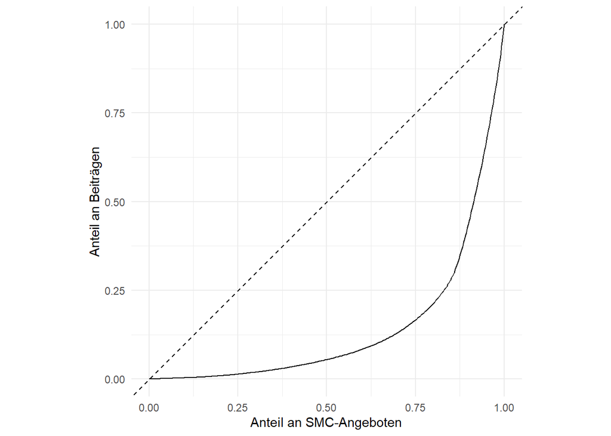

```r
tmp <- reports %>% group_by(storyNo) %>% summarise(n = n())

ggplot(tmp, aes(n)) +
   stat_lorenz() +
   coord_fixed() +
   geom_abline(linetype = "dashed") +
   theme_minimal() +
   labs(x = "Anteil an SMC-Angeboten", y = "Anteil an Beiträgen")
```

```r
Gini(tmp$n)
```

```
## [1] 0.7185952
```

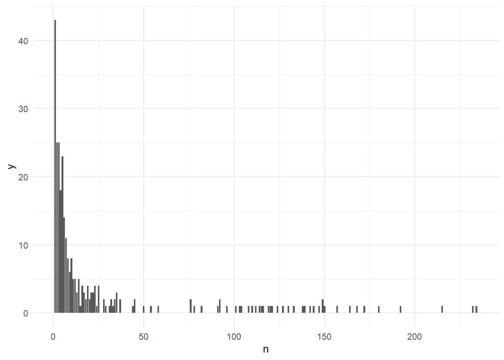

```r
tmp %>% group_by(n) %>% summarise(y = n()) %>%
   ggplot(aes(x = n, y = y)) +
   geom_bar(stat="identity")
```

#### Zu F1.6: Reports pro Agenturmeldung

```r
Agenturstories <- reports %>% filter(modeOfUse == "indirekt via Nachrichtenagentur") %>% group_by(storyNo) %>% summarise(n = n())
t(summary(Agenturstories$n)) %>% kable()
```

| Min. | 1st Qu. | Median | Mean | 3rd Qu. | Max. |
| --- | --- | --- | --- | --- | --- |
| 1 | 8 | 18 | 52.20536 | 98.5 | 231 |

##### Treffer nach *sourceType* und *modeOfUse*.

```r
reports %>% group_by(sourceType) %>% count(modeOfUse) %>% mutate(rel = n / sum(n)) %>%
  group_by() %>%  mutate(rel_gesamt = n / sum(n)) %>%  kable()
```

| sourceType | modeOfUse | n | rel | rel_gesamt |
| --- | --- | --- | --- | --- |
| Anderes | indirekt via SMC Homepage | 1 | 0.5000000 | 0.0001293 |
| Anderes | Themen-/ Expertenfindung | 1 | 0.5000000 | 0.0001293 |
| Nachrichtenagentur |  | 2 | 0.0229885 | 0.0002586 |
| Nachrichtenagentur | direkt via SMC Aussendung (akkreditierte Journalisten) | 38 | 0.4367816 | 0.0049140 |
| Nachrichtenagentur | indirekt via Nachrichtenagentur | 47 | 0.5402299 | 0.0060778 |
| Online |  | 100 | 0.0163265 | 0.0129316 |
| Online | direkt via Press Briefing | 9 | 0.0014694 | 0.0011638 |
| Online | direkt via SMC Aussendung (akkreditierte Journalisten) | 983 | 0.1604898 | 0.1271175 |
| Online | direkt via SMC Int. Aussendung | 9 | 0.0014694 | 0.0011638 |
| Online | indirekt via Nachrichtenagentur | 4867 | 0.7946122 | 0.6293806 |
| Online | indirekt via SMC Homepage | 13 | 0.0021224 | 0.0016811 |
| Online | indirekt via zitierendem Medium | 86 | 0.0140408 | 0.0111212 |
| Online | Themen-/ Expertenfindung | 58 | 0.0094694 | 0.0075003 |
| Print |  | 44 | 0.0295302 | 0.0056899 |
| Print | direkt via Press Briefing | 6 | 0.0040268 | 0.0007759 |
| Print | direkt via SMC Aussendung (akkreditierte Journalisten) | 486 | 0.3261745 | 0.0628475 |
| Print | direkt via SMC Int. Aussendung | 3 | 0.0020134 | 0.0003879 |
| Print | indirekt via Nachrichtenagentur | 923 | 0.6194631 | 0.1193586 |
| Print | indirekt via zitierendem Medium | 17 | 0.0114094 | 0.0021984 |
| Print | Themen-/ Expertenfindung | 11 | 0.0073826 | 0.0014225 |
| Radio |  | 1 | 0.0384615 | 0.0001293 |
| Radio | direkt via Press Briefing | 1 | 0.0384615 | 0.0001293 |
| Radio | direkt via SMC Aussendung (akkreditierte Journalisten) | 2 | 0.0769231 | 0.0002586 |
| Radio | indirekt via Nachrichtenagentur | 8 | 0.3076923 | 0.0010345 |
| Radio | Themen-/ Expertenfindung | 14 | 0.5384615 | 0.0018104 |
| TV | indirekt via Nachrichtenagentur | 2 | 0.6666667 | 0.0002586 |
| TV | Themen-/ Expertenfindung | 1 | 0.3333333 | 0.0001293 |

#### Zu F1.7: Reaktionszeit der Medien

```r
RZ <- reports %>% group_by(storyNo) %>% mutate(lag = published - min(published, na.rm = TRUE))
RZ %>% group_by(mediaOutlet) %>% filter(n() > 5) %>%
  summarise(t0 = sum(lag == 0, na.rm = TRUE),
            t1 = sum(lag == 1, na.rm = TRUE),
            t2 = sum(lag == 2, na.rm = TRUE),
            t3 = sum(lag == 3, na.rm = TRUE),
            t4 = sum(lag == 4, na.rm = TRUE),
            t5 = sum(lag == 5, na.rm = TRUE),
            t6 = sum(lag == 6, na.rm = TRUE),
            t7 = sum(lag == 7, na.rm = TRUE),
            tg7 = sum(lag > 7, na.rm = TRUE),
            mean = round(mean(lag, na.rm = TRUE), 2),
            median = median(lag, na.rm = TRUE)) %>%
  arrange(median, mean) %>% kable()
```

| mediaOutlet | t0 | t1 | t2 | t3 | t4 | t5 | t6 | t7 | tg7 | mean | median |
| --- | --- | --- | --- | --- | --- | --- | --- | --- | --- | --- | --- |
| Finanzen Online AT | 7 | 0 | 0 | 0 | 0 | 0 | 0 | 0 | 0 | 0.00 days | 0.0 days |
| wallstreet-online.de | 6 | 0 | 0 | 0 | 0 | 0 | 0 | 0 | 0 | 0.00 days | 0.0 days |
| onvista.de | 7 | 1 | 0 | 0 | 0 | 0 | 0 | 0 | 0 | 0.12 days | 0.0 days |
| aktiencheck.de | 6 | 1 | 0 | 0 | 0 | 0 | 0 | 0 | 0 | 0.14 days | 0.0 days |
| Hildesheimer Allgemeine Zeitung Online | 5 | 1 | 0 | 0 | 0 | 0 | 0 | 0 | 0 | 0.17 days | 0.0 days |
| regio-news.de | 9 | 2 | 0 | 0 | 0 | 0 | 0 | 0 | 0 | 0.18 days | 0.0 days |
| finanztreff.de | 6 | 2 | 0 | 0 | 0 | 0 | 0 | 0 | 0 | 0.25 days | 0.0 days |
| RND Online | 9 | 3 | 0 | 0 | 0 | 0 | 0 | 0 | 0 | 0.25 days | 0.0 days |
| finanznachrichten.de | 5 | 2 | 0 | 0 | 0 | 0 | 0 | 0 | 0 | 0.29 days | 0.0 days |
| PV Magazine Online | 6 | 0 | 1 | 0 | 0 | 0 | 0 | 0 | 0 | 0.29 days | 0.0 days |
| Finanzen Online DE | 8 | 1 | 1 | 0 | 0 | 0 | 0 | 0 | 0 | 0.30 days | 0.0 days |
| ariva.de | 4 | 2 | 0 | 0 | 0 | 0 | 0 | 0 | 0 | 0.33 days | 0.0 days |
| bbv-net.de | 16 | 8 | 0 | 0 | 0 | 0 | 0 | 0 | 0 | 0.33 days | 0.0 days |
| boerse.de | 4 | 2 | 0 | 0 | 0 | 0 | 0 | 0 | 0 | 0.33 days | 0.0 days |
| Cash Online | 4 | 2 | 0 | 0 | 0 | 0 | 0 | 0 | 0 | 0.33 days | 0.0 days |
| Bild Online | 10 | 3 | 1 | 0 | 0 | 0 | 0 | 0 | 0 | 0.36 days | 0.0 days |
| Schweizer Depeschenagentur (SDA) | 13 | 5 | 1 | 0 | 0 | 0 | 0 | 0 | 0 | 0.37 days | 0.0 days |
| Nordbayern Online | 11 | 5 | 1 | 0 | 0 | 0 | 0 | 0 | 0 | 0.41 days | 0.0 days |
| Walsroder Zeitung Online | 11 | 5 | 1 | 0 | 0 | 0 | 0 | 0 | 0 | 0.41 days | 0.0 days |
| diepresse.com | 4 | 3 | 0 | 0 | 0 | 0 | 0 | 0 | 0 | 0.43 days | 0.0 days |
| Mittelbayerische Zeitung Online | 17 | 5 | 1 | 0 | 1 | 0 | 0 | 0 | 0 | 0.46 days | 0.0 days |
| Elbe-Jeetzel-Zeitung Online | 15 | 6 | 1 | 0 | 1 | 0 | 0 | 0 | 0 | 0.52 days | 0.0 days |
| Radio 912 Online | 8 | 5 | 0 | 0 | 1 | 0 | 0 | 0 | 0 | 0.64 days | 0.0 days |
| Schaumburger Nachrichten Online | 13 | 7 | 0 | 1 | 1 | 0 | 0 | 0 | 0 | 0.64 days | 0.0 days |
| Märkische Oderzeitung Online | 6 | 2 | 0 | 0 | 1 | 0 | 0 | 0 | 0 | 0.67 days | 0.0 days |
| Ostthüringer Zeitung Online | 4 | 2 | 0 | 0 | 1 | 0 | 0 | 0 | 0 | 0.86 days | 0.0 days |
| Frankfurter Neue Presse Online | 18 | 12 | 0 | 0 | 1 | 0 | 0 | 0 | 2 | 0.97 days | 0.0 days |
| Offenbach-Post Online | 7 | 5 | 0 | 0 | 0 | 0 | 0 | 0 | 1 | 1.00 days | 0.0 days |
| Deutsche Presse-Agentur (dpa) | 28 | 9 | 1 | 1 | 0 | 0 | 0 | 0 | 1 | 1.12 days | 0.0 days |
| Landeszeitung für die Lüneburger Heide Online | 25 | 7 | 2 | 0 | 1 | 0 | 0 | 0 | 1 | 1.25 days | 0.0 days |

[output cut: 285 more lines]

##### Media Outlets mit mehr als 10 Treffern

```r
mediaOutletCount <- reports %>% count(mediaOutlet) %>% arrange(desc(n)) %>% filter(n > 10)
mediaOutletCount %>% kable()
```

| mediaOutlet | n |
| --- | --- |
| Süddeutsche Zeitung Online | 107 |
| Die Welt Online | 100 |
| Süddeutsche Zeitung Print | 87 |
| Deutsches Ärzteblatt Online | 85 |
| Focus Online | 76 |
| Der Standard Online AT | 73 |
| Zeit Online | 72 |
| Frankfurter Allgemeine Zeitung Online | 64 |
| Der Spiegel Online | 60 |
| Die Welt Print | 56 |
| Der Tagesspiegel Online | 55 |
| Allgemeine Zeitung Online | 52 |
| Der Tagesspiegel Print | 48 |
| scinexx.de | 48 |
| Stern Online | 48 |
| Schweriner Volkszeitung Online | 45 |
| Leipziger Volkszeitung Online | 43 |
| Neue Osnabrücker Zeitung Online | 43 |
| Berliner Zeitung Print | 42 |
| Lübecker Nachrichten Online | 42 |
| ORF Online | 42 |
| Deutsche Presse-Agentur (dpa) | 41 |
| Frankfurter Rundschau Online | 41 |
| Ostsee-Zeitung Online | 41 |
| Stuttgarter Nachrichten Online | 41 |
| Volksstimme Online | 41 |
| Frankfurter Allgemeine Zeitung Print | 40 |
| Westdeutsche Zeitung Online | 40 |
| Bonner General-Anzeiger Print | 39 |
| N-tv Online | 39 |

[output cut: 177 more lines]

```r
tmp <- RZ %>% group_by(mediaOutlet) %>%
  summarise(t0 = sum(lag == 0, na.rm = TRUE),
            t1 = sum(lag == 1, na.rm = TRUE),
            t2 = sum(lag == 2, na.rm = TRUE),
            t3 = sum(lag == 3, na.rm = TRUE),
            t4 = sum(lag == 4, na.rm = TRUE),
            t5 = sum(lag == 5, na.rm = TRUE),
            t6 = sum(lag == 6, na.rm = TRUE),
            t7 = sum(lag == 7, na.rm = TRUE),
            tg7 = sum(lag > 7, na.rm = TRUE),
            mean = round(mean(lag, na.rm = TRUE), 2),
            median = median(lag, na.rm = TRUE)) %>%
  arrange(median, mean)

reports %>%
   group_by(mediaOutlet) %>%
   summarise(n = n(), Nachrichtenagentur = sum(modeOfUse == "indirekt via Nachrichtenagentur")) %>%
   arrange(desc(n)) %>%
   full_join(tmp, by = "mediaOutlet") %>%
   write_csv("Dynamik_alle_Medien.csv")
```

```r
tmp <- RZ %>%
   filter(!(modeOfUse %in% c("indirekt via Nachrichtenagentur"))) %>%
   group_by(mediaOutlet) %>%
  summarise(t0 = sum(lag == 0, na.rm = TRUE),
            t1 = sum(lag == 1, na.rm = TRUE),
            t2 = sum(lag == 2, na.rm = TRUE),
            t3 = sum(lag == 3, na.rm = TRUE),
            t4 = sum(lag == 4, na.rm = TRUE),
            t5 = sum(lag == 5, na.rm = TRUE),
            t6 = sum(lag == 6, na.rm = TRUE),
            t7 = sum(lag == 7, na.rm = TRUE),
            tg7 = sum(lag > 7, na.rm = TRUE),
            mean = round(mean(lag, na.rm = TRUE), 2),
            median = median(lag, na.rm = TRUE)) %>%
  arrange(median, mean)

reports %>%
   group_by(mediaOutlet) %>%
   summarise(n = n(), Nachrichtenagentur = sum(modeOfUse == "indirekt via Nachrichtenagentur")) %>%
   arrange(desc(n)) %>%
   full_join(tmp, by = "mediaOutlet") %>%
   write_csv("Dynamik_alle_Medien_ohne_NA.csv")
```

#### Zu F1.6: Clustering der mediaOutlets

```r
topOutlets <- reports %>% filter(mediaOutlet %in% mediaOutletCount$mediaOutlet) %>%  group_by(mediaOutlet) %>% count(modeOfUse) %>%
  mutate(modeOfUse = if_else(modeOfUse == "", "NA", modeOfUse)) %>% pivot_wider(names_from = modeOfUse, values_from = n) %>%
  mutate_if(is.integer, function(x)if_else(is.na(x), 0L, x))
```

```
## `mutate_if()` ignored the following grouping variables:
## Column `mediaOutlet`
```

```r
topOutlets <- data.frame(topOutlets)
rownames(topOutlets) <- topOutlets$mediaOutlet
topOutlets <- topOutlets[,-1]
str(topOutlets)
```

```
## 'data.frame':    207 obs. of  8 variables:
##  $ indirekt.via.Nachrichtenagentur                       : int  15 9 20 34 51 11 5 18 31 15 ...
##  $ direkt.via.SMC.Aussendung..akkreditierte.Journalisten.: int  0 2 0 0 1 1 6 11 1 0 ...
##  $ Themen...Expertenfindung                              : int  0 0 0 0 0 0 2 0 0 0 ...
##  $ NA.                                                   : int  0 0 0 0 0 0 0 4 2 0 ...
##  $ indirekt.via.zitierendem.Medium                       : int  0 0 0 0 0 0 0 0 0 0 ...
##  $ direkt.via.SMC.Int..Aussendung                        : int  0 0 0 0 0 0 0 0 0 0 ...
##  $ direkt.via.Press.Briefing                             : int  0 0 0 0 0 0 0 0 0 0 ...
##  $ indirekt.via.SMC.Homepage                             : int  0 0 0 0 0 0 0 0 0 0 ...
```

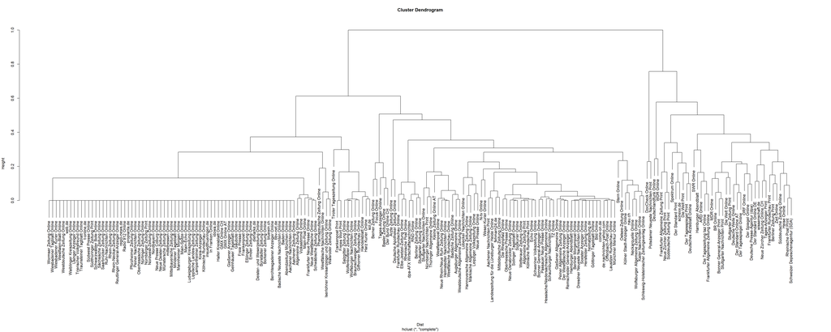

```r
topOutlets <- topOutlets / rowSums(topOutlets)
# Dist <- dist(topOutlets)
Dist <- 1/sqrt(2) * dist(sqrt(topOutlets))

cluster <- hclust(Dist)
plot(cluster)
```

```r
topOutlets <- cbind(n = arrange(mediaOutletCount, mediaOutlet)$n, topOutlets, Clusternummer = cutree(tree = cluster, k = 6))
tmp <- split(topOutlets, topOutlets$Clusternummer)

bind_rows(tibble(tmp[[1]]),
          tibble(tmp[[2]]),
          tibble(tmp[[3]]),
          tibble(tmp[[4]]),
          tibble(tmp[[5]]),
          tibble(tmp[[6]])) %>%
   group_by(Clusternummer) %>%
   summarise(across(everything(), list(median = median))) %>% kable()
```

| Clusternummer | n_median | indirekt.via.Nachrichtenagentur_median | direkt.via.SMC.Aussendung..akkreditierte.Journalisten._median | Themen…Expertenfindung_median | NA._median | indirekt.via.zitierendem.Medium_median | direkt.via.SMC.Int..Aussendung_median | direkt.via.Press.Briefing_median | indirekt.via.SMC.Homepage_median |
| --- | --- | --- | --- | --- | --- | --- | --- | --- | --- |
| 1 | 22.5 | 1.0000000 | 0.0000000 | 0.0000000 | 0.0000000 | 0.0000000 | 0 | 0.0000000 | 0 |
| 2 | 24.0 | 0.9117647 | 0.0769231 | 0.0000000 | 0.0000000 | 0.0000000 | 0 | 0.0000000 | 0 |
| 3 | 38.0 | 0.3500000 | 0.5833333 | 0.0117647 | 0.0166667 | 0.0000000 | 0 | 0.0000000 | 0 |
| 4 | 16.0 | 0.5714286 | 0.2500000 | 0.0000000 | 0.0000000 | 0.1666667 | 0 | 0.0000000 | 0 |
| 5 | 26.5 | 0.1514286 | 0.4364286 | 0.3564286 | 0.0200000 | 0.0000000 | 0 | 0.0357143 | 0 |
| 6 | 11.5 | 0.0000000 | 0.6893939 | 0.0000000 | 0.1780303 | 0.1325758 | 0 | 0.0000000 | 0 |

```r
kable(tmp[[1]], digits = 2)
```

|  | n | indirekt.via.Nachrichtenagentur | direkt.via.SMC.Aussendung..akkreditierte.Journalisten. | Themen…Expertenfindung | NA. | indirekt.via.zitierendem.Medium | direkt.via.SMC.Int..Aussendung | direkt.via.Press.Briefing | indirekt.via.SMC.Homepage | Clusternummer |
| --- | --- | --- | --- | --- | --- | --- | --- | --- | --- | --- |
| Aachener Nachrichten Online | 15 | 1.00 | 0.00 | 0.00 | 0.00 | 0.00 | 0 | 0 | 0 | 1 |
| Aachener Zeitung Online | 20 | 1.00 | 0.00 | 0.00 | 0.00 | 0.00 | 0 | 0 | 0 | 1 |
| Abendzeitung München Online | 34 | 1.00 | 0.00 | 0.00 | 0.00 | 0.00 | 0 | 0 | 0 | 1 |
| Allgemeine Zeitung Online | 52 | 0.98 | 0.02 | 0.00 | 0.00 | 0.00 | 0 | 0 | 0 | 1 |
| Baden Online | 15 | 1.00 | 0.00 | 0.00 | 0.00 | 0.00 | 0 | 0 | 0 | 1 |
| Badische Neueste Nachrichten Online | 32 | 1.00 | 0.00 | 0.00 | 0.00 | 0.00 | 0 | 0 | 0 | 1 |
| bbv-net.de | 24 | 1.00 | 0.00 | 0.00 | 0.00 | 0.00 | 0 | 0 | 0 | 1 |
| Berchtesgadener Anzeiger Online | 13 | 1.00 | 0.00 | 0.00 | 0.00 | 0.00 | 0 | 0 | 0 | 1 |
| bluewin.ch | 14 | 1.00 | 0.00 | 0.00 | 0.00 | 0.00 | 0 | 0 | 0 | 1 |
| Borkener Zeitung Online | 17 | 1.00 | 0.00 | 0.00 | 0.00 | 0.00 | 0 | 0 | 0 | 1 |
| Braunschweiger Zeitung Online | 37 | 0.97 | 0.00 | 0.00 | 0.03 | 0.00 | 0 | 0 | 0 | 1 |
| Bürstädter Zeitung Online | 22 | 1.00 | 0.00 | 0.00 | 0.00 | 0.00 | 0 | 0 | 0 | 1 |
| Deister- und Weserzeitung Online | 23 | 1.00 | 0.00 | 0.00 | 0.00 | 0.00 | 0 | 0 | 0 | 1 |
| dieharke.de | 18 | 1.00 | 0.00 | 0.00 | 0.00 | 0.00 | 0 | 0 | 0 | 1 |
| Emder Zeitung Online | 26 | 1.00 | 0.00 | 0.00 | 0.00 | 0.00 | 0 | 0 | 0 | 1 |
| Eßlinger Zeitung Online | 23 | 1.00 | 0.00 | 0.00 | 0.00 | 0.00 | 0 | 0 | 0 | 1 |
| Frankenpost Online | 22 | 1.00 | 0.00 | 0.00 | 0.00 | 0.00 | 0 | 0 | 0 | 1 |
| Frankenpost Print | 13 | 0.85 | 0.00 | 0.00 | 0.15 | 0.00 | 0 | 0 | 0 | 1 |
| Frankfurter Neue Presse Online | 33 | 0.97 | 0.03 | 0.00 | 0.00 | 0.00 | 0 | 0 | 0 | 1 |
| Freie Presse Online | 36 | 1.00 | 0.00 | 0.00 | 0.00 | 0.00 | 0 | 0 | 0 | 1 |
| Freies Wort Print | 13 | 0.85 | 0.00 | 0.00 | 0.15 | 0.00 | 0 | 0 | 0 | 1 |
| Gäubote Online | 24 | 1.00 | 0.00 | 0.00 | 0.00 | 0.00 | 0 | 0 | 0 | 1 |
| Gelnhäuser Tageblatt Online | 11 | 1.00 | 0.00 | 0.00 | 0.00 | 0.00 | 0 | 0 | 0 | 1 |
| Gießener Anzeiger Online | 23 | 1.00 | 0.00 | 0.00 | 0.00 | 0.00 | 0 | 0 | 0 | 1 |
| Gifhorner Rundschau Online | 35 | 0.97 | 0.00 | 0.00 | 0.03 | 0.00 | 0 | 0 | 0 | 1 |
| GMX Online AT | 15 | 1.00 | 0.00 | 0.00 | 0.00 | 0.00 | 0 | 0 | 0 | 1 |
| GMX Online CH | 11 | 1.00 | 0.00 | 0.00 | 0.00 | 0.00 | 0 | 0 | 0 | 1 |
| Haller Kreisblatt Online | 31 | 1.00 | 0.00 | 0.00 | 0.00 | 0.00 | 0 | 0 | 0 | 1 |
| Handelsblatt Online | 24 | 0.96 | 0.00 | 0.00 | 0.04 | 0.00 | 0 | 0 | 0 | 1 |
| Harz Kurier Online | 18 | 0.94 | 0.00 | 0.00 | 0.06 | 0.00 | 0 | 0 | 0 | 1 |

[output cut: 60 more lines]

```r
kable(tmp[[2]], digits = 2)
```

|  | n | indirekt.via.Nachrichtenagentur | direkt.via.SMC.Aussendung..akkreditierte.Journalisten. | Themen…Expertenfindung | NA. | indirekt.via.zitierendem.Medium | direkt.via.SMC.Int..Aussendung | direkt.via.Press.Briefing | indirekt.via.SMC.Homepage | Clusternummer |
| --- | --- | --- | --- | --- | --- | --- | --- | --- | --- | --- |
| Aachener Nachrichten Print | 11 | 0.82 | 0.18 | 0.00 | 0.00 | 0.00 | 0 | 0 | 0.00 | 2 |
| Allgemeine Zeitung Print | 12 | 0.92 | 0.08 | 0.00 | 0.00 | 0.00 | 0 | 0 | 0.00 | 2 |
| Ärzte Zeitung Online | 33 | 0.55 | 0.33 | 0.00 | 0.12 | 0.00 | 0 | 0 | 0.00 | 2 |
| Augsburger Allgemeine Online | 34 | 0.91 | 0.03 | 0.00 | 0.06 | 0.00 | 0 | 0 | 0.00 | 2 |
| Badische Zeitung Online | 23 | 0.91 | 0.04 | 0.00 | 0.04 | 0.00 | 0 | 0 | 0.00 | 2 |
| Berliner Morgenpost Online | 29 | 0.93 | 0.07 | 0.00 | 0.00 | 0.00 | 0 | 0 | 0.00 | 2 |
| Berliner Zeitung Online | 31 | 0.77 | 0.23 | 0.00 | 0.00 | 0.00 | 0 | 0 | 0.00 | 2 |
| Bild Online | 14 | 0.93 | 0.07 | 0.00 | 0.00 | 0.00 | 0 | 0 | 0.00 | 2 |
| Bonner General-Anzeiger Online | 37 | 0.95 | 0.05 | 0.00 | 0.00 | 0.00 | 0 | 0 | 0.00 | 2 |
| come-on.de | 14 | 0.93 | 0.07 | 0.00 | 0.00 | 0.00 | 0 | 0 | 0.00 | 2 |
| de.nachrichten.yahoo.com | 13 | 0.92 | 0.08 | 0.00 | 0.00 | 0.00 | 0 | 0 | 0.00 | 2 |
| Der Westfälische Anzeiger Online | 16 | 0.94 | 0.06 | 0.00 | 0.00 | 0.00 | 0 | 0 | 0.00 | 2 |
| Deutsche Apotheker Zeitung Online | 12 | 0.50 | 0.25 | 0.00 | 0.25 | 0.00 | 0 | 0 | 0.00 | 2 |
| Die Rheinpfalz Online | 18 | 0.89 | 0.11 | 0.00 | 0.00 | 0.00 | 0 | 0 | 0.00 | 2 |
| dpa-AFX Wirtschaftsnachrichten | 16 | 0.75 | 0.25 | 0.00 | 0.00 | 0.00 | 0 | 0 | 0.00 | 2 |
| Dresdner Neueste Nachrichten Online | 29 | 0.93 | 0.07 | 0.00 | 0.00 | 0.00 | 0 | 0 | 0.00 | 2 |
| Echo Online | 23 | 0.91 | 0.09 | 0.00 | 0.00 | 0.00 | 0 | 0 | 0.00 | 2 |
| Elbe-Jeetzel-Zeitung Online | 23 | 0.70 | 0.30 | 0.00 | 0.00 | 0.00 | 0 | 0 | 0.00 | 2 |
| fehmarn24.de | 14 | 0.86 | 0.14 | 0.00 | 0.00 | 0.00 | 0 | 0 | 0.00 | 2 |
| Frankfurter Rundschau Online | 41 | 0.66 | 0.34 | 0.00 | 0.00 | 0.00 | 0 | 0 | 0.00 | 2 |
| Gießener Allgemeine Online | 17 | 0.94 | 0.06 | 0.00 | 0.00 | 0.00 | 0 | 0 | 0.00 | 2 |
| Göttinger Tageblatt Online | 28 | 0.93 | 0.07 | 0.00 | 0.00 | 0.00 | 0 | 0 | 0.00 | 2 |
| Hamburger Abendblatt Online | 29 | 0.93 | 0.07 | 0.00 | 0.00 | 0.00 | 0 | 0 | 0.00 | 2 |
| Hannoversche Allgemeine Zeitung Online | 36 | 0.89 | 0.08 | 0.00 | 0.00 | 0.00 | 0 | 0 | 0.03 | 2 |
| heimatzeitung.de | 14 | 0.93 | 0.07 | 0.00 | 0.00 | 0.00 | 0 | 0 | 0.00 | 2 |
| Helmstedter Nachrichten Online | 33 | 0.94 | 0.03 | 0.00 | 0.03 | 0.00 | 0 | 0 | 0.00 | 2 |
| Hersfelder Zeitung Online | 14 | 0.93 | 0.07 | 0.00 | 0.00 | 0.00 | 0 | 0 | 0.00 | 2 |
| Hessische/Niedersächsische Allgemeine Online | 24 | 0.96 | 0.04 | 0.00 | 0.00 | 0.00 | 0 | 0 | 0.00 | 2 |
| Kieler Nachrichten Online | 29 | 0.90 | 0.07 | 0.00 | 0.00 | 0.03 | 0 | 0 | 0.00 | 2 |
| Kleine Zeitung Online AT | 17 | 0.82 | 0.06 | 0.00 | 0.12 | 0.00 | 0 | 0 | 0.00 | 2 |
| Kölner Stadt-Anzeiger Online | 21 | 0.86 | 0.10 | 0.00 | 0.00 | 0.05 | 0 | 0 | 0.00 | 2 |
| Kölnische Rundschau Print | 12 | 0.92 | 0.08 | 0.00 | 0.00 | 0.00 | 0 | 0 | 0.00 | 2 |
| Landeszeitung für die Lüneburger Heide Online | 36 | 0.83 | 0.17 | 0.00 | 0.00 | 0.00 | 0 | 0 | 0.00 | 2 |
| Lausitzer Rundschau Online | 27 | 0.93 | 0.07 | 0.00 | 0.00 | 0.00 | 0 | 0 | 0.00 | 2 |
| Leipziger Volkszeitung Online | 43 | 0.84 | 0.14 | 0.00 | 0.00 | 0.00 | 0 | 0 | 0.02 | 2 |
| Lübecker Nachrichten Online | 42 | 0.88 | 0.07 | 0.00 | 0.00 | 0.02 | 0 | 0 | 0.02 | 2 |
| Märkische Allgemeine Zeitung Online | 32 | 0.91 | 0.06 | 0.00 | 0.00 | 0.00 | 0 | 0 | 0.03 | 2 |
| Mitteldeutsche Zeitung Online | 24 | 0.88 | 0.12 | 0.00 | 0.00 | 0.00 | 0 | 0 | 0.00 | 2 |
| Münchner Merkur Online | 27 | 0.93 | 0.07 | 0.00 | 0.00 | 0.00 | 0 | 0 | 0.00 | 2 |
| N-tv Online | 39 | 0.85 | 0.10 | 0.03 | 0.03 | 0.00 | 0 | 0 | 0.00 | 2 |
| nau.ch | 14 | 0.86 | 0.07 | 0.00 | 0.00 | 0.07 | 0 | 0 | 0.00 | 2 |
| Neckarquelle Online | 28 | 0.93 | 0.04 | 0.00 | 0.00 | 0.04 | 0 | 0 | 0.00 | 2 |
| Neue Osnabrücker Zeitung Online | 43 | 0.91 | 0.09 | 0.00 | 0.00 | 0.00 | 0 | 0 | 0.00 | 2 |
| Neue Presse Online | 23 | 0.83 | 0.13 | 0.00 | 0.00 | 0.00 | 0 | 0 | 0.04 | 2 |
| Neue Rhein/Neue Ruhr Zeitung Online | 34 | 0.94 | 0.03 | 0.00 | 0.03 | 0.00 | 0 | 0 | 0.00 | 2 |
| Nürnberger Nachrichten Print | 17 | 0.82 | 0.12 | 0.00 | 0.06 | 0.00 | 0 | 0 | 0.00 | 2 |
| Oberhessische Presse Online | 29 | 0.90 | 0.10 | 0.00 | 0.00 | 0.00 | 0 | 0 | 0.00 | 2 |
| Offenbach-Post Online | 13 | 0.92 | 0.08 | 0.00 | 0.00 | 0.00 | 0 | 0 | 0.00 | 2 |
| Ostsee-Zeitung Online | 41 | 0.85 | 0.12 | 0.00 | 0.00 | 0.02 | 0 | 0 | 0.00 | 2 |
| Passauer Neue Presse Online | 20 | 0.95 | 0.05 | 0.00 | 0.00 | 0.00 | 0 | 0 | 0.00 | 2 |
| Peiner Allgemeine Zeitung Online | 31 | 0.94 | 0.06 | 0.00 | 0.00 | 0.00 | 0 | 0 | 0.00 | 2 |
| Remscheider General-Anzeiger Online | 16 | 0.94 | 0.06 | 0.00 | 0.00 | 0.00 | 0 | 0 | 0.00 | 2 |
| Rheinische Post Online | 17 | 0.71 | 0.29 | 0.00 | 0.00 | 0.00 | 0 | 0 | 0.00 | 2 |
| RND Online | 12 | 0.75 | 0.25 | 0.00 | 0.00 | 0.00 | 0 | 0 | 0.00 | 2 |
| Schaumburger Nachrichten Online | 22 | 0.95 | 0.05 | 0.00 | 0.00 | 0.00 | 0 | 0 | 0.00 | 2 |
| Schleswig-Holsteinischer Zeitungsverlag Online | 37 | 0.92 | 0.05 | 0.00 | 0.00 | 0.03 | 0 | 0 | 0.00 | 2 |
| Schweriner Volkszeitung Online | 45 | 0.91 | 0.09 | 0.00 | 0.00 | 0.00 | 0 | 0 | 0.00 | 2 |
| Soester Anzeiger Online | 14 | 0.93 | 0.07 | 0.00 | 0.00 | 0.00 | 0 | 0 | 0.00 | 2 |
| Solinger Tageblatt Online | 11 | 0.91 | 0.09 | 0.00 | 0.00 | 0.00 | 0 | 0 | 0.00 | 2 |
| Stern Online | 48 | 0.75 | 0.15 | 0.02 | 0.04 | 0.04 | 0 | 0 | 0.00 | 2 |
| Stuttgarter Nachrichten Online | 41 | 0.83 | 0.15 | 0.00 | 0.02 | 0.00 | 0 | 0 | 0.00 | 2 |
| Stuttgarter Zeitung Online | 29 | 0.79 | 0.21 | 0.00 | 0.00 | 0.00 | 0 | 0 | 0.00 | 2 |
| Südkurier Online | 11 | 0.91 | 0.09 | 0.00 | 0.00 | 0.00 | 0 | 0 | 0.00 | 2 |
| Thüringer Allgemeine Online | 15 | 0.80 | 0.13 | 0.00 | 0.07 | 0.00 | 0 | 0 | 0.00 | 2 |
| TZ Online | 21 | 0.95 | 0.05 | 0.00 | 0.00 | 0.00 | 0 | 0 | 0.00 | 2 |
| Weser-Kurier Online | 21 | 0.86 | 0.10 | 0.05 | 0.00 | 0.00 | 0 | 0 | 0.00 | 2 |
| Westdeutsche Allgemeine Zeitung Online | 36 | 0.92 | 0.03 | 0.00 | 0.06 | 0.00 | 0 | 0 | 0.00 | 2 |
| Westfalenpost Online | 38 | 0.95 | 0.03 | 0.00 | 0.03 | 0.00 | 0 | 0 | 0.00 | 2 |
| Westfälische Rundschau Online | 33 | 0.94 | 0.03 | 0.00 | 0.03 | 0.00 | 0 | 0 | 0.00 | 2 |
| Wetterauer Zeitung Online | 12 | 0.92 | 0.08 | 0.00 | 0.00 | 0.00 | 0 | 0 | 0.00 | 2 |
| Wolfsburger Allgemeine Zeitung Online | 26 | 0.92 | 0.04 | 0.00 | 0.00 | 0.04 | 0 | 0 | 0.00 | 2 |

```r
kable(tmp[[3]], digits = 2)
```

|  | n | indirekt.via.Nachrichtenagentur | direkt.via.SMC.Aussendung..akkreditierte.Journalisten. | Themen…Expertenfindung | NA. | indirekt.via.zitierendem.Medium | direkt.via.SMC.Int..Aussendung | direkt.via.Press.Briefing | indirekt.via.SMC.Homepage | Clusternummer |
| --- | --- | --- | --- | --- | --- | --- | --- | --- | --- | --- |
| ARD Online | 13 | 0.38 | 0.46 | 0.15 | 0.00 | 0.00 | 0.00 | 0.00 | 0.00 | 3 |
| Berliner Zeitung Print | 42 | 0.45 | 0.50 | 0.02 | 0.00 | 0.00 | 0.02 | 0.00 | 0.00 | 3 |
| Bonner General-Anzeiger Print | 39 | 0.44 | 0.51 | 0.00 | 0.05 | 0.00 | 0.00 | 0.00 | 0.00 | 3 |
| BR Online | 13 | 0.38 | 0.54 | 0.00 | 0.08 | 0.00 | 0.00 | 0.00 | 0.00 | 3 |
| Der Spiegel Online | 60 | 0.50 | 0.47 | 0.02 | 0.02 | 0.00 | 0.00 | 0.00 | 0.00 | 3 |
| Der Standard Online AT | 73 | 0.33 | 0.62 | 0.01 | 0.04 | 0.00 | 0.00 | 0.00 | 0.00 | 3 |
| Der Standard Online DE | 38 | 0.37 | 0.61 | 0.00 | 0.00 | 0.03 | 0.00 | 0.00 | 0.00 | 3 |
| Der Standard Print | 34 | 0.12 | 0.82 | 0.00 | 0.03 | 0.03 | 0.00 | 0.00 | 0.00 | 3 |
| Der Tagesspiegel Online | 55 | 0.27 | 0.67 | 0.02 | 0.04 | 0.00 | 0.00 | 0.00 | 0.00 | 3 |
| Der Tagesspiegel Print | 48 | 0.15 | 0.81 | 0.02 | 0.02 | 0.00 | 0.00 | 0.00 | 0.00 | 3 |
| Deutsche Presse-Agentur (dpa) | 41 | 0.54 | 0.44 | 0.00 | 0.02 | 0.00 | 0.00 | 0.00 | 0.00 | 3 |
| Deutsche Welle Online | 29 | 0.38 | 0.55 | 0.03 | 0.03 | 0.00 | 0.00 | 0.00 | 0.00 | 3 |
| Deutsches Ärzteblatt Online | 85 | 0.09 | 0.86 | 0.01 | 0.02 | 0.00 | 0.00 | 0.01 | 0.00 | 3 |
| Die Tageszeitung taz Online | 11 | 0.36 | 0.55 | 0.09 | 0.00 | 0.00 | 0.00 | 0.00 | 0.00 | 3 |
| Die Welt Online | 100 | 0.35 | 0.55 | 0.00 | 0.07 | 0.01 | 0.00 | 0.02 | 0.00 | 3 |
| Die Welt Print | 56 | 0.20 | 0.73 | 0.00 | 0.05 | 0.00 | 0.00 | 0.02 | 0.00 | 3 |
| Frankfurter Allgemeine Zeitung Online | 64 | 0.38 | 0.56 | 0.06 | 0.00 | 0.00 | 0.00 | 0.00 | 0.00 | 3 |
| Frankfurter Allgemeine Zeitung Print | 40 | 0.05 | 0.80 | 0.10 | 0.03 | 0.00 | 0.00 | 0.03 | 0.00 | 3 |
| Frankfurter Rundschau Print | 36 | 0.53 | 0.44 | 0.00 | 0.00 | 0.00 | 0.03 | 0.00 | 0.00 | 3 |
| Hamburger Abendblatt | 12 | 0.58 | 0.33 | 0.08 | 0.00 | 0.00 | 0.00 | 0.00 | 0.00 | 3 |
| Heise Online | 20 | 0.35 | 0.65 | 0.00 | 0.00 | 0.00 | 0.00 | 0.00 | 0.00 | 3 |
| MDR Online | 24 | 0.29 | 0.58 | 0.00 | 0.12 | 0.00 | 0.00 | 0.00 | 0.00 | 3 |
| Neue Zürcher Zeitung Online CH | 38 | 0.21 | 0.76 | 0.03 | 0.00 | 0.00 | 0.00 | 0.00 | 0.00 | 3 |
| Neue Zürcher Zeitung Print | 26 | 0.08 | 0.85 | 0.04 | 0.00 | 0.00 | 0.00 | 0.04 | 0.00 | 3 |
| ORF Online | 42 | 0.48 | 0.45 | 0.00 | 0.05 | 0.00 | 0.00 | 0.00 | 0.02 | 3 |
| Rheinische Post Print | 11 | 0.45 | 0.55 | 0.00 | 0.00 | 0.00 | 0.00 | 0.00 | 0.00 | 3 |
| Schweizer Depeschenagentur (SDA) | 19 | 0.47 | 0.53 | 0.00 | 0.00 | 0.00 | 0.00 | 0.00 | 0.00 | 3 |
| scinexx.de | 48 | 0.12 | 0.79 | 0.02 | 0.02 | 0.04 | 0.00 | 0.00 | 0.00 | 3 |
| Spektrum Online | 27 | 0.07 | 0.70 | 0.04 | 0.15 | 0.00 | 0.00 | 0.00 | 0.04 | 3 |
| Stuttgarter Nachrichten Print | 18 | 0.44 | 0.50 | 0.00 | 0.06 | 0.00 | 0.00 | 0.00 | 0.00 | 3 |
| Stuttgarter Zeitung Print | 31 | 0.42 | 0.45 | 0.00 | 0.10 | 0.03 | 0.00 | 0.00 | 0.00 | 3 |
| Süddeutsche Zeitung Online | 107 | 0.32 | 0.65 | 0.00 | 0.00 | 0.00 | 0.00 | 0.02 | 0.01 | 3 |
| Süddeutsche Zeitung Print | 87 | 0.07 | 0.89 | 0.02 | 0.00 | 0.00 | 0.00 | 0.02 | 0.00 | 3 |
| SWR Online | 17 | 0.24 | 0.59 | 0.12 | 0.00 | 0.06 | 0.00 | 0.00 | 0.00 | 3 |
| Tages-Anzeiger Print | 13 | 0.23 | 0.77 | 0.00 | 0.00 | 0.00 | 0.00 | 0.00 | 0.00 | 3 |
| wissenschaft.de | 17 | 0.24 | 0.71 | 0.00 | 0.00 | 0.06 | 0.00 | 0.00 | 0.00 | 3 |
| Zeit Online | 72 | 0.40 | 0.56 | 0.01 | 0.00 | 0.01 | 0.01 | 0.00 | 0.00 | 3 |

```r
kable(tmp[[4]], digits = 2)
```

|  | n | indirekt.via.Nachrichtenagentur | direkt.via.SMC.Aussendung..akkreditierte.Journalisten. | Themen…Expertenfindung | NA. | indirekt.via.zitierendem.Medium | direkt.via.SMC.Int..Aussendung | direkt.via.Press.Briefing | indirekt.via.SMC.Homepage | Clusternummer |
| --- | --- | --- | --- | --- | --- | --- | --- | --- | --- | --- |
| Basler Zeitung Online | 16 | 0.56 | 0.25 | 0 | 0.00 | 0.19 | 0 | 0 | 0 | 4 |
| Berner Zeitung Online | 12 | 0.67 | 0.17 | 0 | 0.00 | 0.17 | 0 | 0 | 0 | 4 |
| Der Bund Online CH | 13 | 0.46 | 0.31 | 0 | 0.00 | 0.23 | 0 | 0 | 0 | 4 |
| Focus Online | 76 | 0.72 | 0.18 | 0 | 0.01 | 0.08 | 0 | 0 | 0 | 4 |
| Tages-Anzeiger Online | 21 | 0.57 | 0.33 | 0 | 0.00 | 0.10 | 0 | 0 | 0 | 4 |

```r
kable(tmp[[5]], digits = 2)
```

|  | n | indirekt.via.Nachrichtenagentur | direkt.via.SMC.Aussendung..akkreditierte.Journalisten. | Themen…Expertenfindung | NA. | indirekt.via.zitierendem.Medium | direkt.via.SMC.Int..Aussendung | direkt.via.Press.Briefing | indirekt.via.SMC.Homepage | Clusternummer |
| --- | --- | --- | --- | --- | --- | --- | --- | --- | --- | --- |
| Deutschlandfunk Online | 28 | 0.14 | 0.39 | 0.39 | 0.00 | 0 | 0 | 0.07 | 0 | 5 |
| WDR Online | 25 | 0.16 | 0.48 | 0.32 | 0.04 | 0 | 0 | 0.00 | 0 | 5 |

```r
kable(tmp[[6]], digits = 2)
```

|  | n | indirekt.via.Nachrichtenagentur | direkt.via.SMC.Aussendung..akkreditierte.Journalisten. | Themen…Expertenfindung | NA. | indirekt.via.zitierendem.Medium | direkt.via.SMC.Int..Aussendung | direkt.via.Press.Briefing | indirekt.via.SMC.Homepage | Clusternummer |
| --- | --- | --- | --- | --- | --- | --- | --- | --- | --- | --- |
| DocCheck Online | 11 | 0 | 0.55 | 0 | 0.27 | 0.18 | 0 | 0 | 0 | 6 |
| Potsdamer Neueste Nachrichten Print | 12 | 0 | 0.83 | 0 | 0.08 | 0.08 | 0 | 0 | 0 | 6 |

### Top Stories

Stories mit mindestens 100 Treffern beim Pressclipping.

```r
TopStories <- left_join(reports, storyData, by = "storyNo") %>% filter(!(modeOfUse == "Themen-/ Expertenfindung")) %>% group_by(storyNo) %>%
   filter(storyType %in% c("Research in Context", "Rapid Reaction")) %>%  summarize(AnzTreffer = n()) %>%
   filter(AnzTreffer >= 100)
TopStories <- left_join(TopStories, storyData, by = "storyNo")
# write.csv(TopStories %>% select(-responsible, -responsibleSecondary), fileEncoding = "UTF-8", file = "tab_TopStories.csv")
kable(TopStories)
```

| storyNo | AnzTreffer | storyType | responsible | responsibleSecondary | subject | journal | ressort | storyDate | Jahr | Monat |
| --- | --- | --- | --- | --- | --- | --- | --- | --- | --- | --- |
| 17030 | 104 | Research in Context | Volker Stollorz | Volker Stollorz | Frühchen-Lämmer in künstlicher Fruchtblase herangereift | Nature Communications | Medizin | 2017-04-25 | 2017-01-01 | 2017-04-01 |
| 17052 | 192 | Research in Context | Franziska Badenschier | Franziska Badenschier | Spermien-Zahl sinkt weiterhin | Human Reproductive Update | Medizin | 2017-07-25 | 2017-01-01 | 2017-07-01 |
| 17053 | 148 | Research in Context | Franziska Badenschier | Franziska Badenschier | CRISPR-Cas9 kann mutierte Erbanlage in menschlichen Embryonen korrigieren | Nature | Medizin | 2017-08-02 | 2017-01-01 | 2017-08-01 |
| 17067 | 211 | Research in Context | Silvio Wenzel | Silvio Wenzel | Rückgang der Insektenbiomasse um über 75 Prozent | PLOS ONE | Umwelt | 2017-10-18 | 2017-01-01 | 2017-10-01 |
| 17069 | 144 | Research in Context | Volker Stollorz | Volker Stollorz | Transplantation gentherapierter Haut bei hautkrankem Jungen in Deutschland erfolgreich | Nature | Medizin | 2017-11-08 | 2017-01-01 | 2017-11-01 |
| 18005 | 150 | Research in Context | Volker Stollorz | Volker Stollorz | Erstmals Javaneraffen geklont durch “Dolly”-Methode | Cell | Medizin | 2018-01-24 | 2018-01-01 | 2018-01-01 |
| 18019 | 133 | Rapid Reaction | Sönke Gäthke | Sönke Gäthke | Kosovo und Serbien lassen Europas Uhren nachgehen |  | Technik | 2018-03-06 | 2018-01-01 | 2018-03-01 |
| 18020 | 127 | Research in Context | Sönke Gäthke | Sönke Gäthke | 6000 vorzeitige Todesfälle durch NO |  | Technik | 2018-03-08 | 2018-01-01 | 2018-03-01 |
| 18026 | 142 | Research in Context | Silvio Wenzel | Silvio Wenzel | Ein Drittel Gletscherrückgang auch ohne weitere Emissionen | Nature Climate Change | Klima | 2018-03-19 | 2018-01-01 | 2018-03-01 |
| 18027 | 120 | Rapid Reaction | Sönke Gäthke | Sönke Gäthke | UBER-Unfall: Welche Rolle spielte die Technik? |  | Technik | 2018-03-21 | 2018-01-01 | 2018-03-01 |
| 18028 | 138 | Research in Context | Franziska Badenschier | Franziska Badenschier | 100g/Wo Alkohol als (neuer) Schwellenwert für risikoarmen Konsum | The Lancet | Lebenswiss. | 2018-04-13 | 2018-01-01 | 2018-04-01 |
| 18033 | 119 | Research in Context | Franziska Badenschier | Franziska Badenschier | HPV-Impfung bei Mädchen laut Cochrane Review sicher und effektiv | Cochrane | Medizin | 2018-05-09 | 2018-01-01 | 2018-05-01 |
| 18040 | 115 | Research in Context | Volker Stollorz | Volker Stollorz | Evolutionäre Gehirnvergrößerung beim Menschen erklärt? | Cell | Medizin | 2018-05-31 | 2018-01-01 | 2018-05-01 |
| 18075 | 172 | Research in Context | Franziska Badenschier | Franziska Badenschier | Querschnittsgelähmter läuft Schritte mit Rückenmark-Stimulation | Nature Medicine | Medizin | 2018-09-24 | 2018-01-01 | 2018-09-01 |
| 18079 | 149 | Research in Context | Silvio Wenzel | Silvio Wenzel | IPCC-Sonderbericht zum Erreichen des 1,5-Grad-Ziels |  | Umwelt | 2018-10-08 | 2018-01-01 | 2018-10-01 |
| 18081 | 180 | Research in Context | Sophie Rotgeri | Sophie Rotgeri | Welcher Ethik sollten autonome Autos folgen? | Nature | Technik | 2018-10-24 | 2018-01-01 | 2018-10-01 |
| 18093 | 234 | Rapid Reaction | Marleen Halbach | Marleen Halbach | Erstmals geneditierte Babys in China geboren |  | Medizin | 2018-11-26 | 2018-01-01 | 2018-11-01 |
| 18096 | 130 | Research in Context | Volker Stollorz | Volker Stollorz | Paviane überleben mit Schweineherz längere Zeit | Nature | Medizin | 2018-12-05 | 2018-01-01 | 2018-12-01 |
| 19012 | 116 | Research in Context | Sophie Rotgeri | Sophie Rotgeri | Algorithmus diagnostiziert Kinderkrankheiten im Krankenhaus | Nature Medicine | Technik | 2019-02-11 | 2019-01-01 | 2019-02-01 |
| 19018 | 147 | Research in Context | Marleen Halbach | Marleen Halbach | HIV-Patient frei von Symptomen nach Knochenmarkstransplantation | Nature | Medizin | 2019-03-05 | 2019-01-01 | 2019-03-01 |
| 19044 | 167 | Research in Context | Marleen Halbach | Marleen Halbach | Fertiggerichte lassen Menschen mehr essen | Cell Metabolism | Lebenswiss. | 2019-05-16 | 2019-01-01 | 2019-05-01 |
| 19048 | 231 | Rapid Reaction | Annegret Burkert | Annegret Burkert | Geburten nach Uterus-Transplantation in Deutschland |  | Medizin | 2019-05-22 | 2019-01-01 | 2019-05-01 |
| 19058 | 102 | Research in Context | Heinz Greuling | Heinz Greuling | Weltweites Experiment: Konflikt zwischen Ehrlichkeit und Eigennutz | Science | Lebenswiss. | 2019-06-20 | 2019-01-01 | 2019-06-01 |
| 19063 | 110 | Research in Context | Bastian Zimmermann | Bastian Zimmermann | Künftige fossile Kraftwerke bedrohen 1,5-Grad-Ziel | Nature | Klima | 2019-07-01 | 2019-01-01 | 2019-07-01 |
| 19065 | 112 | Research in Context | Silvio Wenzel | Silvio Wenzel | Weltweit verfügbare Flächen zur Aufforstung zum Klimaschutz | Science | Klima | 2019-07-04 | 2019-01-01 | 2019-07-01 |
| 19067 | 121 | Research in Context | Bastian Zimmermann | Bastian Zimmermann | Poker-KI Pluribus schlägt menschliche Profis im Texas Hold‘em mit sechs Spielern | Science | Technik | 2019-07-11 | 2019-01-01 | 2019-07-01 |
| 19080 | 163 | Research in Context | Silvio Wenzel | Silvio Wenzel | IPCC Sonderbericht über Klimawandel und Landsysteme |  | Klima | 2019-08-08 | 2019-01-01 | 2019-08-01 |
| 19086 | 135 | Research in Context | Bastian Zimmermann | Bastian Zimmermann | WHO Bericht zu Mikroplastik im Trinkwasser |  | Umwelt | 2019-08-22 | 2019-01-01 | 2019-08-01 |
| 19088 | 122 | Rapid Reaction | Bastian Zimmermann | Bastian Zimmermann | G7 soll über Waldbrände in Brasilien sprechen |  | Umwelt | 2019-08-23 | 2019-01-01 | 2019-08-01 |
| 19127 | 157 | Research in Context | Heinz Greuling | Heinz Greuling | Gesundheitliche Folgen des Klimawandels | The Lancet Countdown | Medizin | 2019-11-14 | 2019-01-01 | 2019-11-01 |

#### Expert*innen der Top Stories

```r
TopExperts <- experts %>% filter(experts$storyNo %in% TopStories$storyNo)
# write.csv(TopExperts %>% select(storyNo, displayName, currentEmployer), fileEncoding = "UTF-8", file = "tab_TopExperts.csv")
```

### sampling

```r
reports100 <- reports %>% filter(storyNo %in% TopStories$storyNo & !(modeOfUse == "Themen-/ Expertenfindung"))
# reports100 %>% filter(sourceType == "Nachrichtenagentur") %>% group_by(storyNo) %>% view() #summarise(n = n()) %>% kable()
# reports100 %>% filter(modeOfUse == "indirekt via Nachrichtenagentur") %>% group_by(storyNo) %>% summarise(n = n()) %>% kable()
# reports100 %>% filter(!(modeOfUse == "indirekt via Nachrichtenagentur")) %>% group_by(storyNo) %>% summarise(n = n()) %>% kable()
reports100filter <- reports100 %>% filter(!(modeOfUse == "indirekt via Nachrichtenagentur") | sourceType == "Nachrichtenagentur")

PCKontrollen <- read.csv(file = "PressClipping_Kontrollen_fSampleMerge.csv", fileEncoding = "UTF-8", stringsAsFactors = FALSE, sep = ";")
PCKontrollenFilter <- PCKontrollen %>% filter(Medium %in% reports100filter$mediaOutlet)



# write.csv(reports100, fileEncoding = "UTF-8", file = "tab_reports100.csv")
# write.csv(reports100filter, fileEncoding = "UTF-8", file = "tab_reports100filter.csv")
set.seed(19096)
sampleID <- sample(1:nrow(reports100filter))
sampleIDKontrolle <- sample(1:nrow(PCKontrollenFilter))

# write.csv(select(reports100filter, storyNo, Treffer, published, title, mediaOutlet, uri)[sampleID[1:12],], fileEncoding = "UTF-8", file = "CA_pretest2.csv")
# write.csv(select(reports100filter, storyNo, Treffer, published, title, mediaOutlet, uri)[sampleID[13:132],], fileEncoding = "UTF-8", file = "CA_SMC.csv")

# write.csv(PCKontrollenFilter[sampleIDKontrolle[1:12],], fileEncoding = "UTF-8", file = "CA_pretest2_Kontrolle.csv")

# write.csv(PCKontrollenFilter[sampleIDKontrolle[13:132],], fileEncoding = "UTF-8", file = "CA_Kontrolle.csv")
# write.csv(PCKontrollenFilter[sampleIDKontrolle[133:142],], fileEncoding = "UTF-8", file = "CA_pretest3_Kontrolle.csv")
```

```r
tmp <- select(reports100filter, storyNo, Treffer, published, title, mediaOutlet, uri)[sampleID[13:132],]
# write.csv(paste0("Ident-Nr. global: ", tmp$storyNo, "\nIdent-Nr. Beitrag ", tmp$Treffer, "\n\nText: \n\n", tmp$mediaOutlet, ": ", tmp$title," (", tmp$published, ")\n\nLink: ", tmp$uri), fileEncoding = "UTF-8", file = "CA_SMC_word.csv")
tmp <- select(reports100filter, storyNo, Treffer, published, title, mediaOutlet, uri)[sampleID[133:143],]
# write.csv(paste0("Ident-Nr. global: ", tmp$storyNo, "\nIdent-Nr. Beitrag ", tmp$Treffer, "\n\nText: \n\n", tmp$mediaOutlet, ": ", tmp$title," (", tmp$published, ")\n\nLink: ", tmp$uri), fileEncoding = "UTF-8", file = "CA_SMC_pretest3_word.csv")



tmp <- PCKontrollenFilter[sampleIDKontrolle[1:12],]
# write.csv(paste0("Ident-Nr. global: ", tmp$Laufnummer, "\nIdent-Nr. Beitrag ", rownames(tmp), "\n\nText: \n\n", tmp$Medium, ":  (", tmp$Datum, ")\n\nLink: ", tmp$URL.Quelle.PDF..Text), fileEncoding = "UTF-8", file = "CA_pretest2_Kontrolle_word.csv")

tmp <- PCKontrollenFilter[sampleIDKontrolle[13:132],]
# write.csv(paste0("Ident-Nr. global: ", tmp$Laufnummer, "\nIdent-Nr. Beitrag ", rownames(tmp), "\n\nText: \n\n", tmp$Medium, ":  (", tmp$Datum, ")\n\nLink: ", tmp$URL.Quelle.PDF..Text), fileEncoding = "UTF-8", file = "CA_Kontrolle_word.csv")

tmp <- PCKontrollenFilter[sampleIDKontrolle[133:145],]
# write.csv(paste0("Ident-Nr. global: ", tmp$Laufnummer, "\nIdent-Nr. Beitrag ", rownames(tmp), "\n\nText: \n\n", tmp$Medium, ":  (", tmp$Datum, ")\n\nLink: ", tmp$URL.Quelle.PDF..Text), fileEncoding = "UTF-8", file = "CA_pretest3_Kontrolle_word.csv")
```